# EmployeePromotionPrediction

```python
import warnings

warnings.filterwarnings("ignore")

import pandas as pd
import numpy as np

import matplotlib.pyplot as plt
import seaborn as sns


from sklearn import metrics
from sklearn.model_selection import train_test_split, StratifiedKFold, cross_val_score
from sklearn.preprocessing import StandardScaler
from sklearn.model_selection import GridSearchCV, RandomizedSearchCV

from sklearn.impute import KNNImputer
from sklearn.pipeline import Pipeline, make_pipeline


from sklearn.linear_model import LogisticRegression
from sklearn.tree import DecisionTreeClassifier
from sklearn.ensemble import (
    AdaBoostClassifier,
    GradientBoostingClassifier,
    RandomForestClassifier,
    BaggingClassifier)
from xgboost import XGBClassifier


pd.set_option('display.float_format', lambda x: '%.3f' % x)
```

```python
data=pd.read_csv(r'C:\Users\davis\OneDrive\Desktop\Python\Model Tuning\employee_promotion.csv')
```

```python
copy = data.copy()
```

```python
data.head()
```

|  | employee_id | department | region | education | gender | recruitment_channel | no_of_trainings | age | previous_year_rating | length_of_service | awards_won | avg_training_score | is_promoted |
| --- | --- | --- | --- | --- | --- | --- | --- | --- | --- | --- | --- | --- | --- |
| 0 | 65438 | Sales & Marketing | 7 | Masters & above | f | sourcing | 1 | 35 | 5.000 | 8 | 0 | 49.000 | 0 |
| 1 | 65141 | Operations | 22 | Bachelors | m | other | 1 | 30 | 5.000 | 4 | 0 | 60.000 | 0 |
| 2 | 7513 | Sales & Marketing | 19 | Bachelors | m | sourcing | 1 | 34 | 3.000 | 7 | 0 | 50.000 | 0 |
| 3 | 2542 | Sales & Marketing | 23 | Bachelors | m | other | 2 | 39 | 1.000 | 10 | 0 | 50.000 | 0 |
| 4 | 48945 | Technology | 26 | Bachelors | m | other | 1 | 45 | 3.000 | 2 | 0 | 73.000 | 0 |

```python
data.tail()
```

|  | employee_id | department | region | education | gender | recruitment_channel | no_of_trainings | age | previous_year_rating | length_of_service | awards_won | avg_training_score | is_promoted |
| --- | --- | --- | --- | --- | --- | --- | --- | --- | --- | --- | --- | --- | --- |
| 54803 | 3030 | Technology | 14 | Bachelors | m | sourcing | 1 | 48 | 3.000 | 17 | 0 | 78.000 | 0 |
| 54804 | 74592 | Operations | 27 | Masters & above | f | other | 1 | 37 | 2.000 | 6 | 0 | 56.000 | 0 |
| 54805 | 13918 | Analytics | 1 | Bachelors | m | other | 1 | 27 | 5.000 | 3 | 0 | 79.000 | 0 |
| 54806 | 13614 | Sales & Marketing | 9 | NaN | m | sourcing | 1 | 29 | 1.000 | 2 | 0 | nan | 0 |
| 54807 | 51526 | HR | 22 | Bachelors | m | other | 1 | 27 | 1.000 | 5 | 0 | 49.000 | 0 |

```python
data.shape
```

```
(54808, 13)
```

```python
data.info()
```

```
<class 'pandas.core.frame.DataFrame'>
RangeIndex: 54808 entries, 0 to 54807
Data columns (total 13 columns):
 #   Column                Non-Null Count  Dtype
---  ------                --------------  -----
 0   employee_id           54808 non-null  int64
 1   department            54808 non-null  object
 2   region                54808 non-null  int64
 3   education             52399 non-null  object
 4   gender                54808 non-null  object
 5   recruitment_channel   54808 non-null  object
 6   no_of_trainings       54808 non-null  int64
 7   age                   54808 non-null  int64
 8   previous_year_rating  50684 non-null  float64
 9   length_of_service     54808 non-null  int64
 10  awards_won            54808 non-null  int64
 11  avg_training_score    52248 non-null  float64
 12  is_promoted           54808 non-null  int64
dtypes: float64(2), int64(7), object(4)
memory usage: 5.4+ MB
```

```python
data.describe().T
```

|  | count | mean | std | min | 25% | 50% | 75% | max |
| --- | --- | --- | --- | --- | --- | --- | --- | --- |
| employee_id | 54808.000 | 39195.831 | 22586.581 | 1.000 | 19669.750 | 39225.500 | 58730.500 | 78298.000 |
| region | 54808.000 | 14.195 | 10.086 | 1.000 | 4.000 | 13.000 | 22.000 | 34.000 |
| no_of_trainings | 54808.000 | 1.253 | 0.609 | 1.000 | 1.000 | 1.000 | 1.000 | 10.000 |
| age | 54808.000 | 34.804 | 7.660 | 20.000 | 29.000 | 33.000 | 39.000 | 60.000 |
| previous_year_rating | 50684.000 | 3.329 | 1.260 | 1.000 | 3.000 | 3.000 | 4.000 | 5.000 |
| length_of_service | 54808.000 | 5.866 | 4.265 | 1.000 | 3.000 | 5.000 | 7.000 | 37.000 |
| awards_won | 54808.000 | 0.023 | 0.150 | 0.000 | 0.000 | 0.000 | 0.000 | 1.000 |
| avg_training_score | 52248.000 | 63.712 | 13.522 | 39.000 | 51.000 | 60.000 | 77.000 | 99.000 |
| is_promoted | 54808.000 | 0.085 | 0.279 | 0.000 | 0.000 | 0.000 | 0.000 | 1.000 |

employee_id can be dropped. no_of_trainings average is 1.253, range is 1 to 10. age average is 34.8, range is 20 to 60. previous_year_rating average is 3.329, range 1 to 5. length_of_service average is 5.9, range 1 to 37. awards won average is .023, range 0 to 1. avg_training_score average is 63.7, range is 39 to 99. is_promoted is yes or no 0 ot 1

```python
data.drop(['employee_id'],axis=1,inplace=True)
```

```python
data.describe(include=['object']).T
```

|  | count | unique | top | freq |
| --- | --- | --- | --- | --- |
| department | 54808 | 9 | Sales & Marketing | 16840 |
| education | 52399 | 3 | Bachelors | 36669 |
| gender | 54808 | 2 | m | 38496 |
| recruitment_channel | 54808 | 3 | other | 30446 |

```python
for i in data.describe(include=['object']).columns:
    print('Unique values in',i, 'are :')
    print(data[i].value_counts())
    print('*'*50)
```

```
Unique values in department are :
Sales & Marketing    16840
Operations           11348
Procurement           7138
Technology            7138
Analytics             5352
Finance               2536
HR                    2418
Legal                 1039
R&D                    999
Name: department, dtype: int64
Unique values in education are :
Bachelors          36669
Masters & above    14925
Below Secondary      805
Name: education, dtype: int64
Unique values in gender are :
m    38496
f    16312
Name: gender, dtype: int64
Unique values in recruitment_channel are :
other       30446
sourcing    23220
referred     1142
Name: recruitment_channel, dtype: int64
```

Most of the employees are in Sales & Marketing and Operations. Most employees are in region_2. Most employees have a Bachelor's degree. Most employees are Male. Most employees were recruited through "other" means.

```python
def histogram_boxplot(feature, figsize=(15,10), bins = None):
    """ Boxplot and histogram combined
    feature: 1-d feature array
    figsize: size of fig (default (9,8))
    bins: number of bins (default None / auto)
    """
    f2, (ax_box2, ax_hist2) = plt.subplots(nrows = 2,
                                           sharex = True,
                                           gridspec_kw = {"height_ratios": (.25, .75)},
                                           figsize = figsize
                                           )
    sns.boxplot(feature, ax=ax_box2, showmeans=True, color='violet')
    sns.distplot(feature, kde=F, ax=ax_hist2, bins=bins,color = 'orange') if bins else sns.distplot(feature, kde=False, ax=ax_hist2,color='tab:cyan') # For histogram
    ax_hist2.axvline(np.mean(feature), color='purple', linestyle='--')
    ax_hist2.axvline(np.median(feature), color='black', linestyle='-')
```

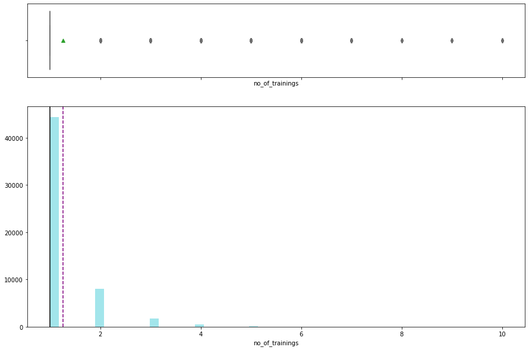

```python
histogram_boxplot(data['no_of_trainings'])
```

Most employees have had one training. There are outliers according to box plot.

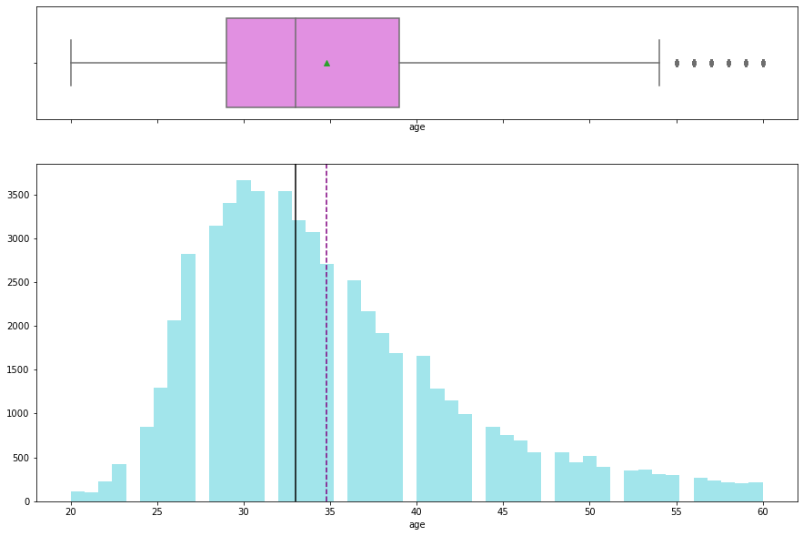

```python
histogram_boxplot(data['age'])
```

Average age about 34. Right skewed data. Most employees between 25 and 45. Outliers outside right whisker for older age.

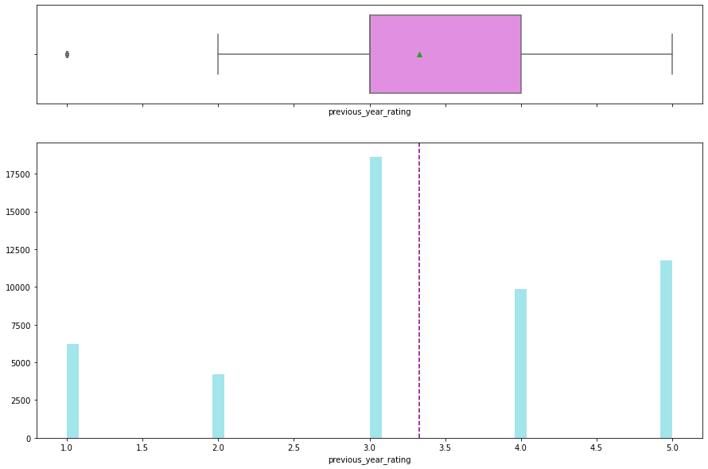

```python
histogram_boxplot(data['previous_year_rating'])
```

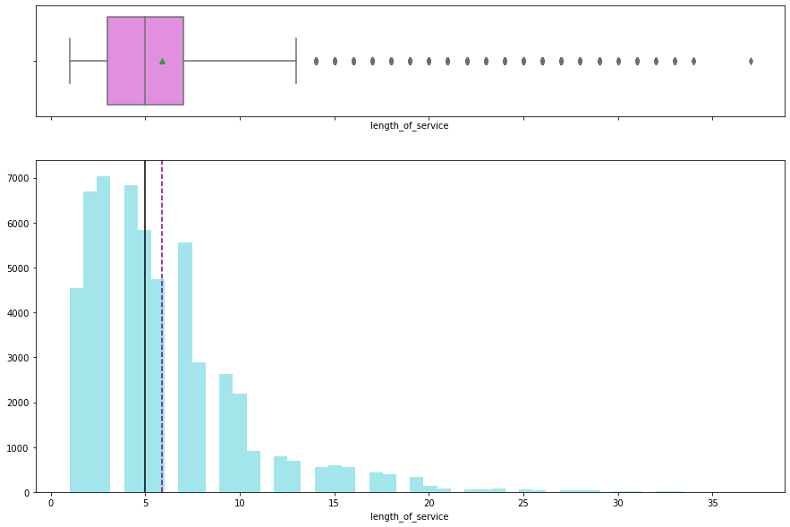

```python
histogram_boxplot(data['length_of_service'])
```

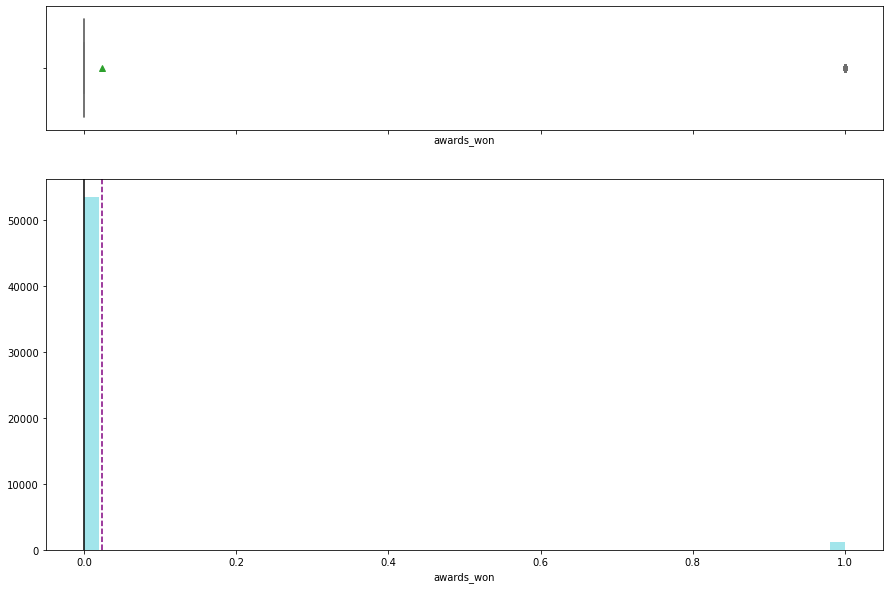

```python
histogram_boxplot(data['awards_won'])
```

Average awards won is 0. Very few have won awards.

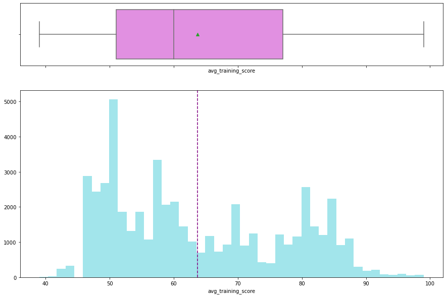

```python
histogram_boxplot(data['avg_training_score'])
```

Average training score is 63. Right skewed. Four peaks in the data around 50, 58, 70, and 80. No outliers.

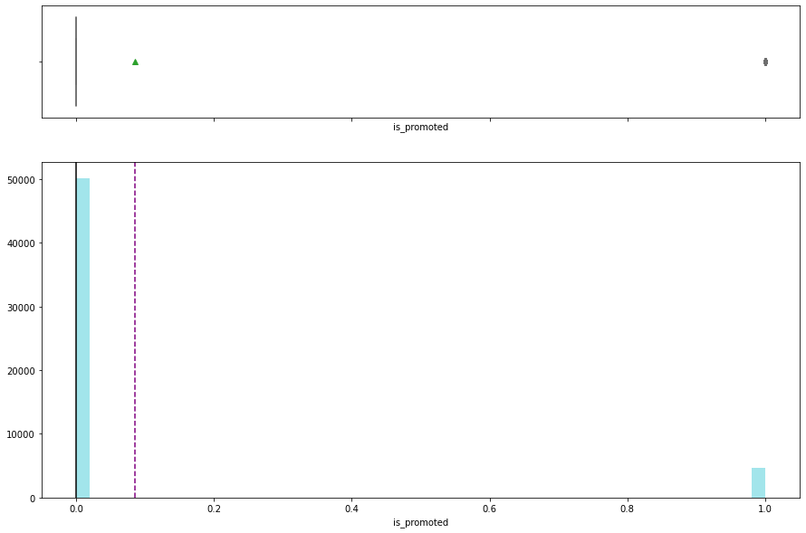

```python
histogram_boxplot(data['is_promoted'])
```

Most employees not promoted.

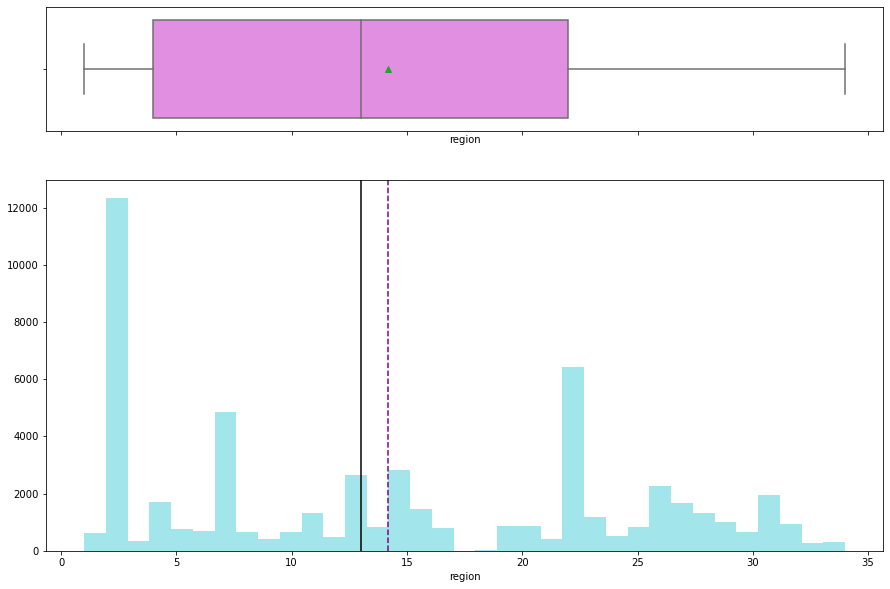

```python
histogram_boxplot(data['region'])
```

```python
def perc_on_bar(z):
    '''
    plot
    feature: categorical feature
    the function won't work if a column is passed in hue parameter
    '''

    total = len(data[z])
    plt.figure(figsize=(15,5))
    ax = sns.countplot(data[z],palette='Paired')
    for p in ax.patches:
        percentage = '{:.1f}%'.format(100 * p.get_height()/total)
        x = p.get_x() + p.get_width() / 2 - 0.05
        y = p.get_y() + p.get_height()

        ax.annotate(percentage, (x, y), size = 12)
    plt.show()
```

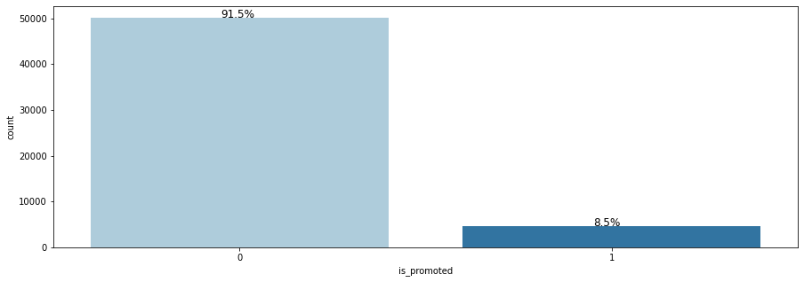

```python
perc_on_bar('is_promoted')
```

Very few empoyees are promoted.

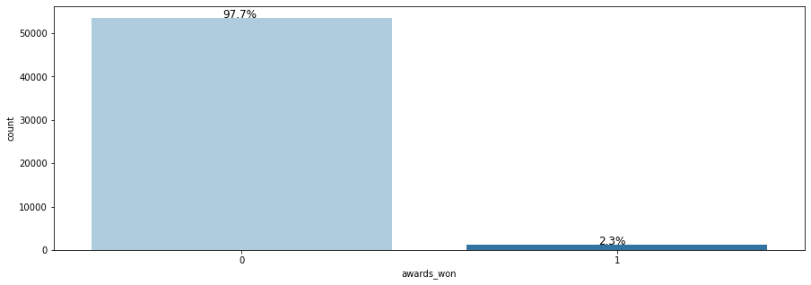

```python
perc_on_bar('awards_won')
```

Most employees have not won an award.

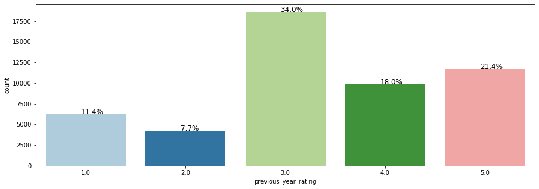

```python
perc_on_bar('previous_year_rating')
```

73.4% of employees have a 3 or higher rating.

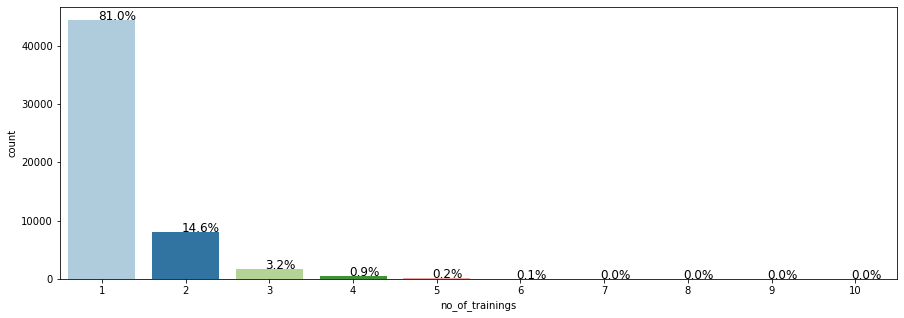

```python
perc_on_bar('no_of_trainings')
```

Most employees have only had 1 training.

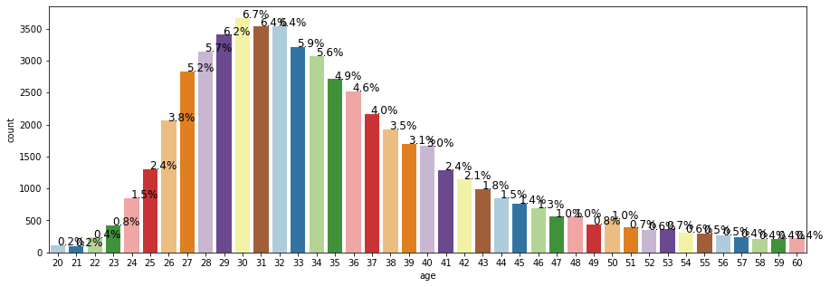

```python
perc_on_bar('age')
```

Most employees between 25 and 45.

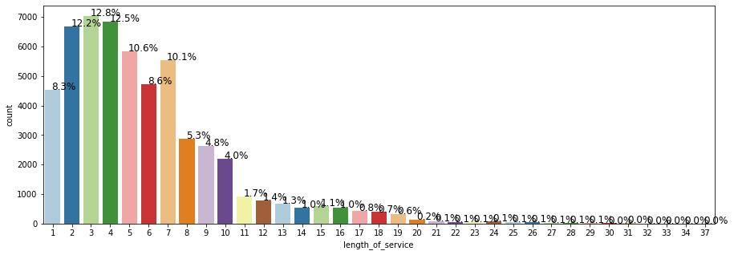

```python
perc_on_bar('length_of_service')
```

Most employees have between 1 and 10 years of service.

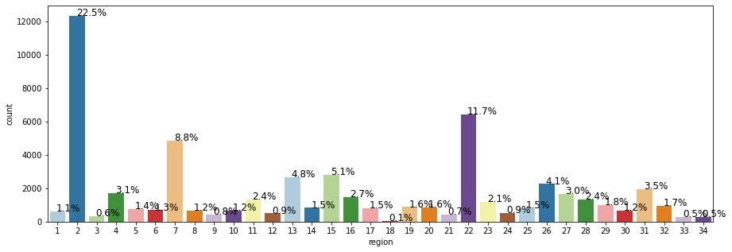

```python
perc_on_bar('region')
```

22.5% employees in region 2.

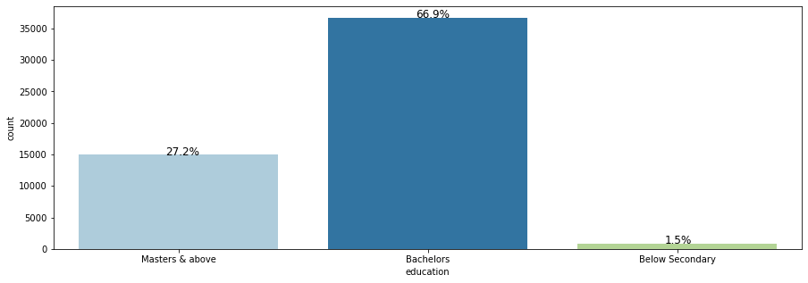

```python
perc_on_bar('education')
```

Most employees have a bachelor's degree. Very few have below.

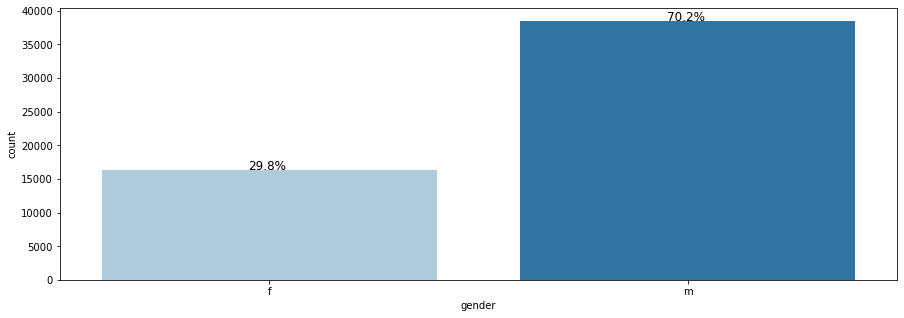

```python
perc_on_bar('gender')
```

Most employees are male.

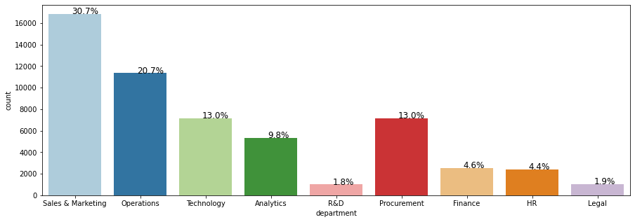

```python
perc_on_bar('department')
```

51.4% of employees are in Sales & Marketing or Operations.

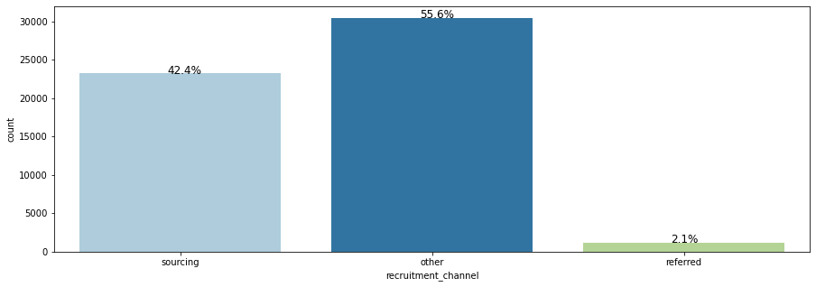

```python
perc_on_bar('recruitment_channel')
```

Most employees were recruited by "other" means, followed by sourcing. Very few referred.

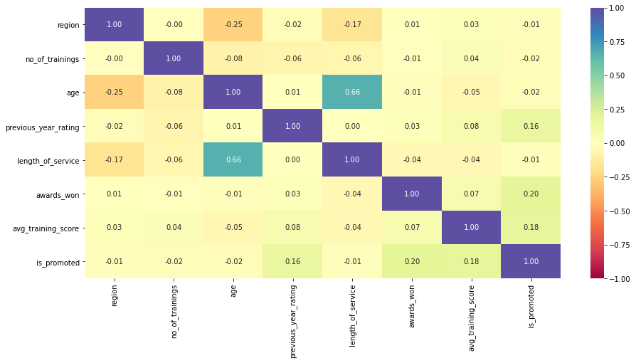

```python
plt.figure(figsize=(15,7))
sns.heatmap(data.corr(),annot=True,vmin=-1,vmax=1,fmt='.2f',cmap='Spectral')
plt.show()
```

Correlation between length of service and age.

```python
def stacked_plot(x):
    sns.set()

    tab1 = pd.crosstab(x,data['is_promoted'],margins=True).sort_values(by=1,ascending=False)
    print(tab1)
    print('-'*120)

    tab = pd.crosstab(x,data['is_promoted'],normalize='index').sort_values(by=1,ascending=False)
    tab.plot(kind='bar',stacked=True,figsize=(17,7))
    plt.legend(loc='lower left', frameon=False,)
    plt.legend(loc="upper left", bbox_to_anchor=(1,1))
    plt.show()
```

```
is_promoted      0     1    All
gender
All          50140  4668  54808
m            35295  3201  38496
f            14845  1467  16312
------------------------------------------------------------------------------------------------------------------------
```

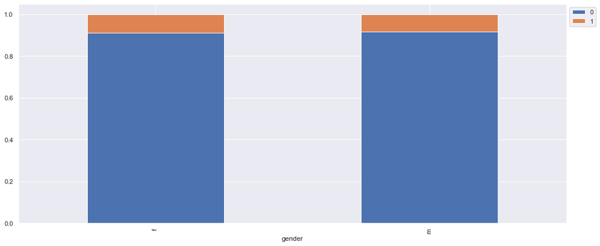

```python
stacked_plot(data['gender'])
```

Not much difference in promotions between males and females.

```
is_promoted          0     1    All
education
All              47853  4546  52399
Bachelors        33661  3008  36669
Masters & above  13454  1471  14925
Below Secondary    738    67    805
------------------------------------------------------------------------------------------------------------------------
```

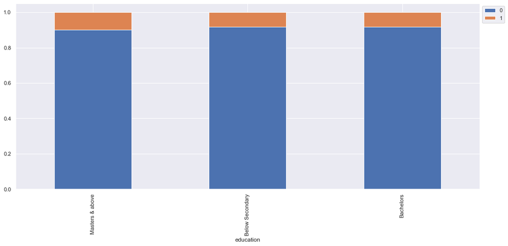

```python
stacked_plot(data['education'])
```

Very little difference in promotions in education.

```
is_promoted      0     1    All
awards_won
All          50140  4668  54808
0            49429  4109  53538
1              711   559   1270
------------------------------------------------------------------------------------------------------------------------
```

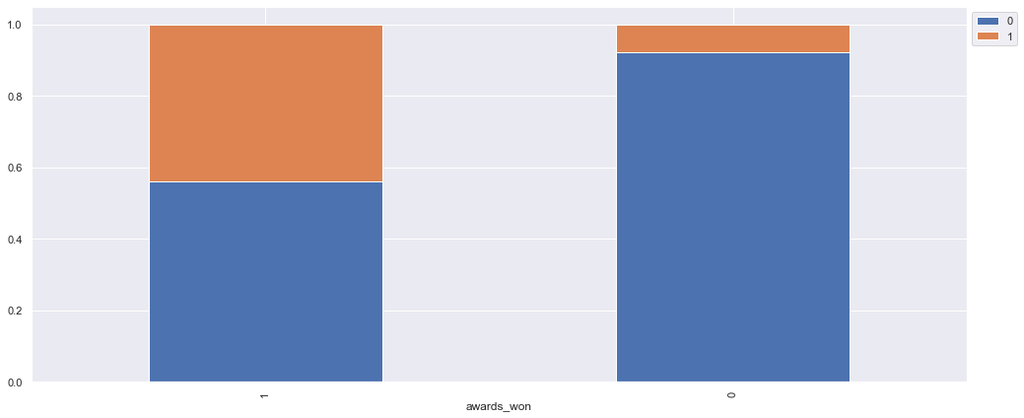

```python
stacked_plot(data['awards_won'])
```

```
is_promoted               0     1    All
previous_year_rating
All                   46355  4329  50684
5.0                    9820  1921  11741
3.0                   17263  1355  18618
4.0                    9093   784   9877
2.0                    4044   181   4225
1.0                    6135    88   6223
------------------------------------------------------------------------------------------------------------------------
```

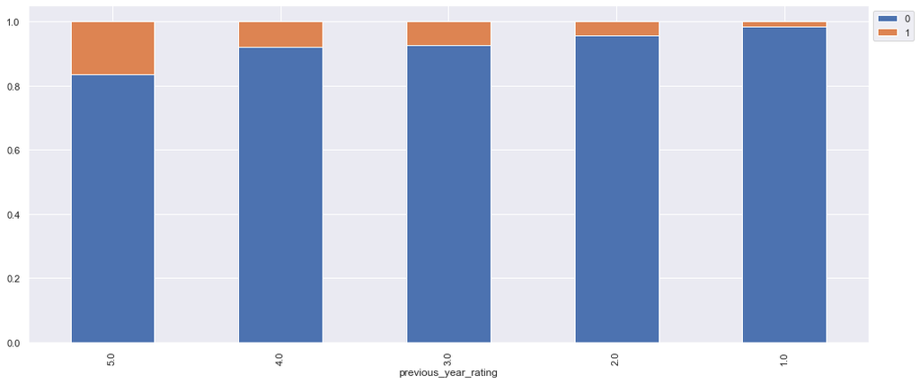

```python
stacked_plot(data['previous_year_rating'])
```

Employees with previous year rating of 5 are most likely to get promotions. Lower rating the lower chance of promotion.

```
is_promoted          0     1    All
no_of_trainings
All              50140  4668  54808
1                40468  3910  44378
2                 7382   605   7987
3                 1654   122   1776
4                  442    26    468
5                  125     3    128
6                   42     2     44
7                   12     0     12
8                    5     0      5
9                    5     0      5
10                   5     0      5
------------------------------------------------------------------------------------------------------------------------
```

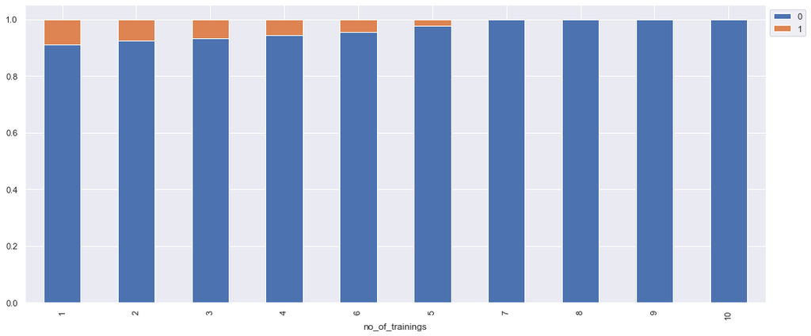

```python
stacked_plot(data['no_of_trainings'])
```

Fewer the trainings the higher chance of promotion. More than likely because most employees have only one training.

```
is_promoted            0     1    All
length_of_service
All                50140  4668  54808
3                   6424   609   7033
4                   6238   598   6836
2                   6089   595   6684
5                   5357   475   5832
7                   5087   464   5551
6                   4333   401   4734
1                   4170   377   4547
8                   2614   269   2883
9                   2400   229   2629
10                  1989   204   2193
11                   820    96    916
12                   731    63    794
```

[output cut: 24 more lines]

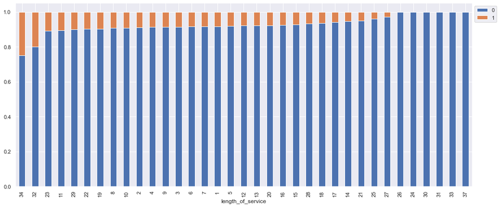

```python
stacked_plot(data['length_of_service'])
```

```
is_promoted      0     1    All
region
All          50140  4668  54808
2            11354   989  12343
22            5694   734   6428
7             4327   516   4843
4             1457   246   1703
13            2418   230   2648
15            2586   222   2808
28            1164   154   1318
26            2117   143   2260
23            1038   137   1175
27            1528   131   1659
31            1825   110   1935
17             687   109    796
```

[output cut: 23 more lines]

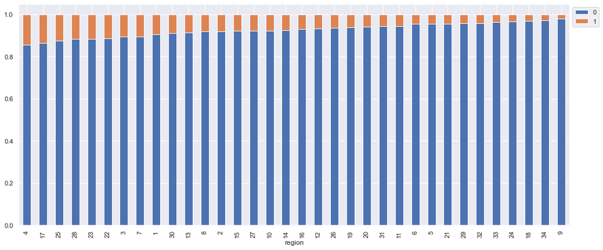

```python
stacked_plot(data['region'])
```

Region 4, 17, and 25 seem to have most promotions.

```
is_promoted            0     1    All
department
All                50140  4668  54808
Sales & Marketing  15627  1213  16840
Operations         10325  1023  11348
Technology          6370   768   7138
Procurement         6450   688   7138
Analytics           4840   512   5352
Finance             2330   206   2536
HR                  2282   136   2418
R&D                  930    69    999
Legal                986    53   1039
------------------------------------------------------------------------------------------------------------------------
```

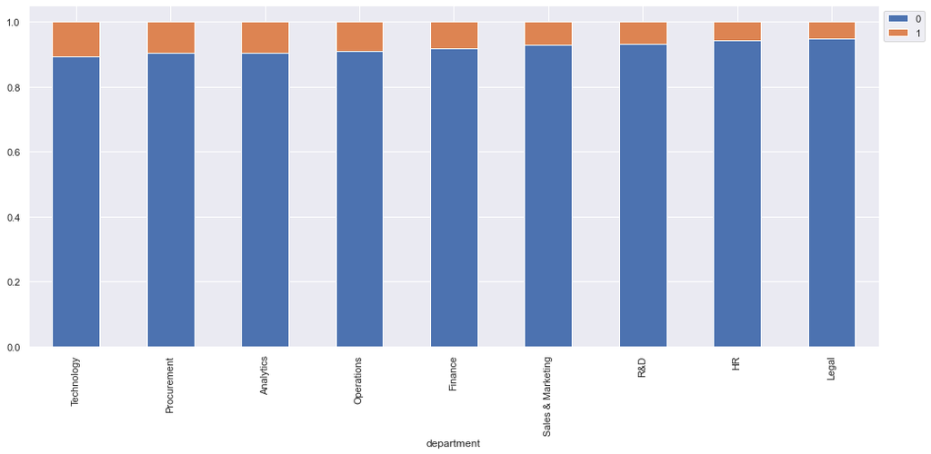

```python
stacked_plot(data['department'])
```

Technology, procurement, and analystics appear to have most promotions.

```
is_promoted              0     1    All
recruitment_channel
All                  50140  4668  54808
other                27890  2556  30446
sourcing             21246  1974  23220
referred              1004   138   1142
------------------------------------------------------------------------------------------------------------------------
```

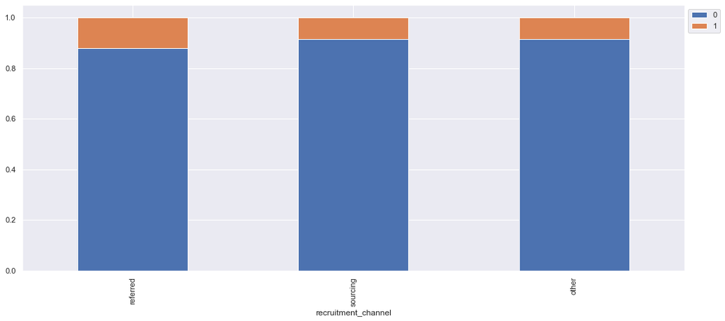

```python
stacked_plot(data['recruitment_channel'])
```

Referred employees appear to have most promotions.

```
is_promoted      0     1    All
age
All          50140  4668  54808
30            3341   324   3665
33            2891   319   3210
31            3224   310   3534
28            2839   308   3147
32            3237   297   3534
29            3111   294   3405
34            2790   286   3076
35            2428   283   2711
27            2566   261   2827
36            2309   208   2517
38            1739   184   1923
37            1981   184   2165
```

[output cut: 30 more lines]

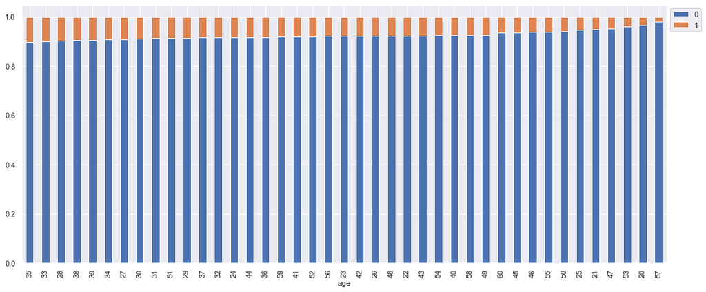

```python
stacked_plot(data['age'])
```

Employees in their 30s appear to have most promotions.

```
is_promoted             0     1    All
avg_training_score
All                 47757  4491  52248
82.0                 1296   151   1447
81.0                 1208   149   1357
59.0                 1919   145   2064
60.0                 2017   138   2155
58.0                 1768   130   1898
83.0                 1071   127   1198
70.0                  932   123   1055
86.0                  792   120    912
84.0                 1048   120   1168
80.0                 1086   120   1206
62.0                 1333   117   1450
50.0                 2604   112   2716
71.0                  790   108    898
85.0                  967   105   1072
51.0                 2244   103   2347
49.0                 2581   100   2681
48.0                 2341    96   2437
69.0                  922    96   1018
63.0                  927    94   1021
78.0                  845    88    933
72.0                  639    86    725
87.0                  571    84    655
89.0                  217    84    301
79.0                 1076    84   1160
88.0                  362    82    444
57.0                 1355    82   1437
64.0                  627    81    708
92.0                   18    81     99
90.0                  106    79    185
47.0                 1667    79   1746
68.0                  858    77    935
91.0                   41    76    117
93.0                    9    75     84
67.0                  654    74    728
74.0                  359    74    433
52.0                 1784    72   1856
56.0                 1001    69   1070
```

[output cut: 8 more lines]

```
55.0                  825    47    872
76.0                  469    47    516
96.0                    1    47     48
95.0                    0    45     45
53.0                 1280    44   1324
98.0                    0    37     37
46.0                 1100    36   1136
99.0                    0    35     35
44.0                  325    10    335
43.0                  169     7    176
42.0                   60     2     62
41.0                   25     1     26
40.0                    5     0      5
39.0                    2     0      2
------------------------------------------------------------------------------------------------------------------------
```

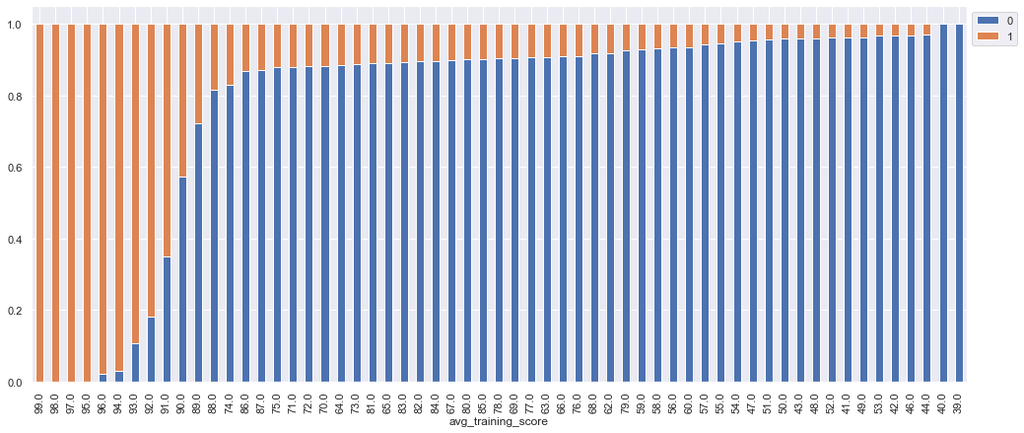

```python
stacked_plot(data['avg_training_score'])
```

Higher average training scores more likely to receive promotions.

```python
def plot(x,target='is_promoted'):
    fig,axs = plt.subplots(2,2,figsize=(12,10))
    axs[0, 0].set_title('Distribution of an Employee Promoted')
    sns.distplot(data[(data[target] == 1)][x],ax=axs[0,0],color='teal')
    axs[0, 1].set_title('Distribution of an Employee not Promoted')
    sns.distplot(data[(data[target] == 0)][x],ax=axs[0,1],color='orange')
    axs[1,0].set_title('Boxplot w.r.t is_promoted')
    sns.boxplot(data[target],data[x],ax=axs[1,0],palette='gist_rainbow')
    axs[1,1].set_title('Boxplot w.r.t is_promoted - Without outliers')
    sns.boxplot(data[target],data[x],ax=axs[1,1],showfliers=False,palette='gist_rainbow')
    plt.tight_layout()
    plt.show()
```

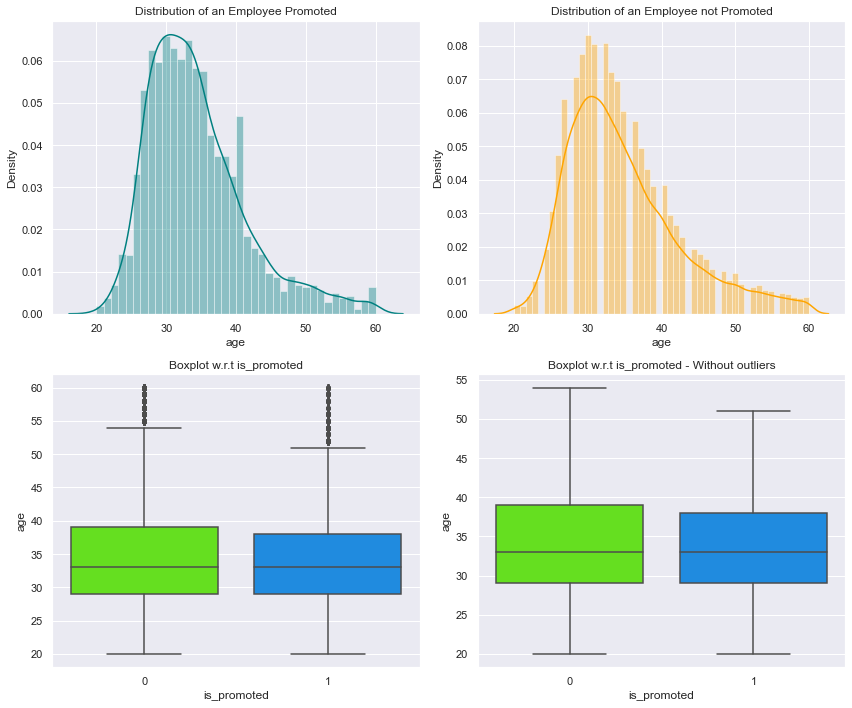

```python
plot('age')
```

Little difference between age in those promoted and those not.

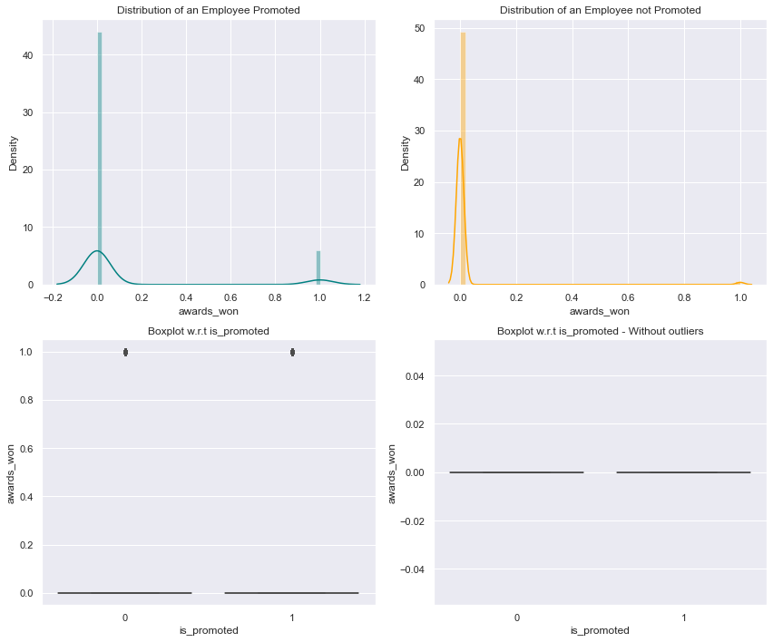

```python
plot('awards_won')
```

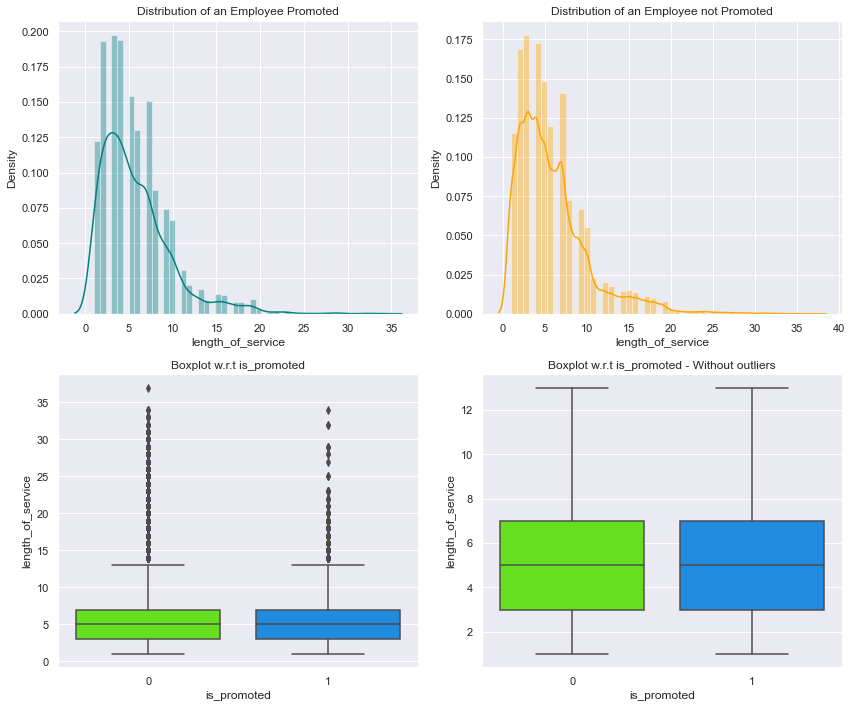

```python
plot('length_of_service')
```

Very little difference.

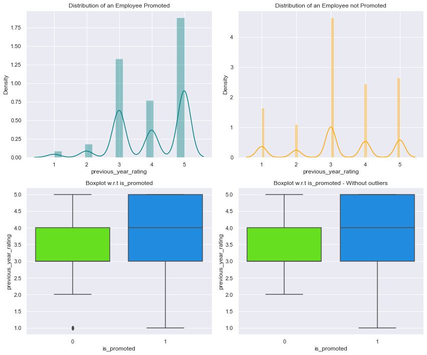

```python
plot('previous_year_rating')
```

Previous year rating 5 higher chance of promotions.

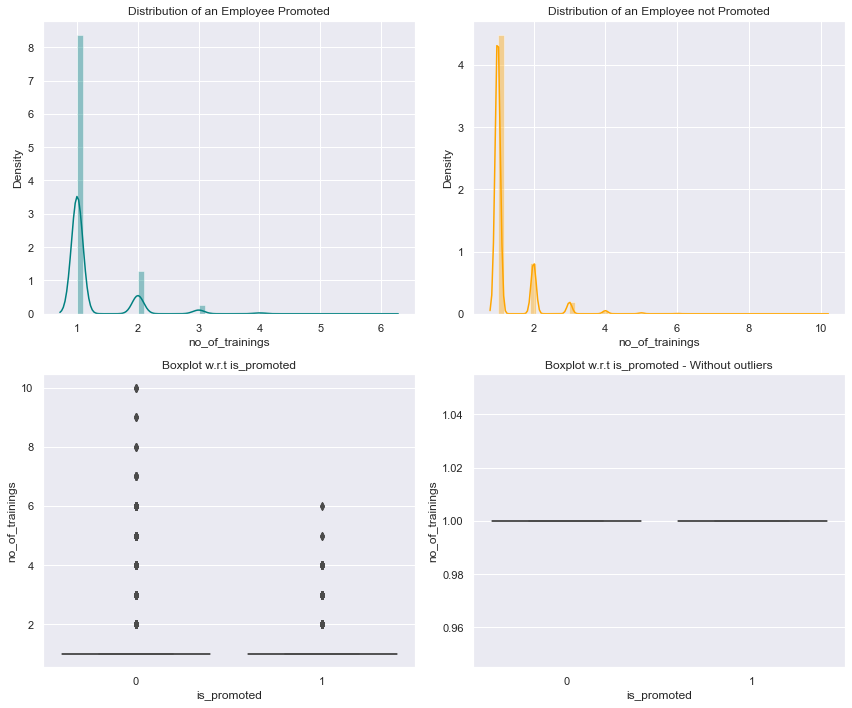

```python
plot('no_of_trainings')
```

Very little difference.

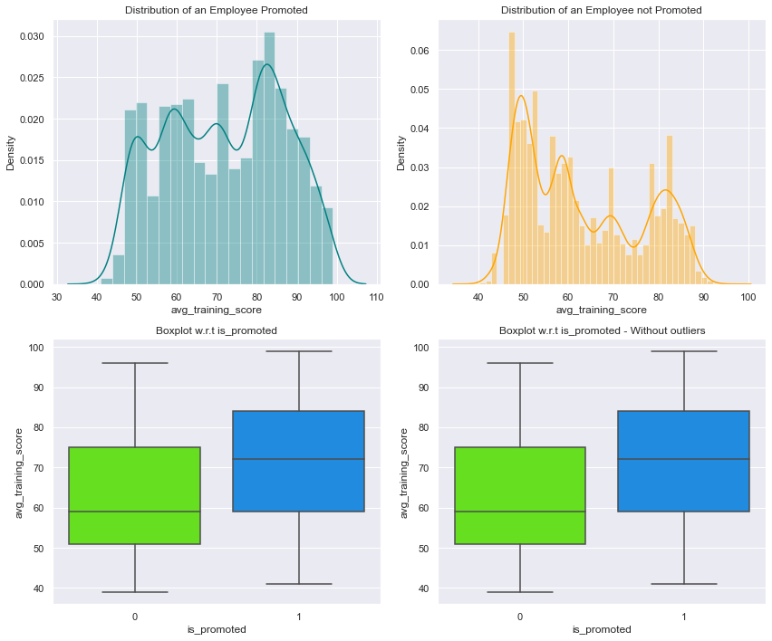

```python
plot('avg_training_score')
```

Higher scores appear to have higher chance of promotions.

```python
Q1 = data.quantile(0.25)             #To find the 25th percentile and 75th percentile.
Q3 = data.quantile(0.75)

IQR = Q3 - Q1                           #Inter Quantile Range (75th perentile - 25th percentile)

lower=Q1-1.5*IQR                        #Finding lower and upper bounds for all values. All values outside these bounds are outliers
upper=Q3+1.5*IQR
```

```python
((data.select_dtypes(include=['float64','int64'])<lower) | (data.select_dtypes(include=['float64','int64'])>upper)).sum()/len(data)*100
```

```
region                  0.000
no_of_trainings        19.030
age                     2.618
previous_year_rating   11.354
length_of_service       6.366
awards_won              2.317
avg_training_score      0.000
is_promoted             8.517
dtype: float64
```

Not treating outliers as the data is useful.

```python
data1=data.copy()
```

# Numerical values for each catergorical column for KNN imputation so we will label encode them

```python
gender = {'m':0,'f':1}
data1['gender'] = data1['gender'].map(gender).astype('Int32')

education= {'Below Secondary':0, 'Bachelors':1,'Masters & Above':2}
data1['education'] = data1['education'].map(education).astype('Int32')

recruitment_channel = {'other':0, 'sourcing':1,'referred':2}
data1['recruitment_channel'] = data1['recruitment_channel'].map(recruitment_channel).astype('Int32')

department = {'Sales & Marketing':0,'Operations':1,'Procurement':2 ,'Technology':3,'Analytics':4, 'Finance':5, 'HR':6, 'Legal':7, 'R&D':8}
data1['department'] = data1['department'].map(department).astype('Int32')
```

```python
data1.head()
```

|  | department | region | education | gender | recruitment_channel | no_of_trainings | age | previous_year_rating | length_of_service | awards_won | avg_training_score | is_promoted |
| --- | --- | --- | --- | --- | --- | --- | --- | --- | --- | --- | --- | --- |
| 0 | 0 | 7 | <NA> | 1 | 1 | 1 | 35 | 5.000 | 8 | 0 | 49.000 | 0 |
| 1 | 1 | 22 | 1 | 0 | 0 | 1 | 30 | 5.000 | 4 | 0 | 60.000 | 0 |
| 2 | 0 | 19 | 1 | 0 | 1 | 1 | 34 | 3.000 | 7 | 0 | 50.000 | 0 |
| 3 | 0 | 23 | 1 | 0 | 0 | 2 | 39 | 1.000 | 10 | 0 | 50.000 | 0 |
| 4 | 3 | 26 | 1 | 0 | 0 | 1 | 45 | 3.000 | 2 | 0 | 73.000 | 0 |

# Missing Value Treatment

```python
data1.isnull().sum()
```

```
department                  0
region                      0
education               17334
gender                      0
recruitment_channel         0
no_of_trainings             0
age                         0
previous_year_rating     4124
length_of_service           0
awards_won                  0
avg_training_score       2560
is_promoted                 0
dtype: int64
```

```python
imputer = KNNImputer(n_neighbors=5)
```

```python
X = data1.drop(['is_promoted'],axis=1)
y = data1['is_promoted']
```

```python
X_train, X_test, y_train, y_test = train_test_split(X, y, test_size=0.3, random_state=7,stratify=y)
print(X_train.shape, X_test.shape)
```

```
(38365, 11) (16443, 11)
```

```python
X_train=pd.DataFrame(imputer.fit_transform(X_train),columns=X_train.columns)

X_test=pd.DataFrame(imputer.transform(X_test),columns=X_test.columns)
```

```python
print(X_train.isna().sum())
print('-'*30)
print(X_test.isna().sum())
```

```
department              0
region                  0
education               0
gender                  0
recruitment_channel     0
no_of_trainings         0
age                     0
previous_year_rating    0
length_of_service       0
awards_won              0
avg_training_score      0
dtype: int64
------------------------------
department              0
region                  0
education               0
gender                  0
recruitment_channel     0
no_of_trainings         0
age                     0
previous_year_rating    0
length_of_service       0
awards_won              0
avg_training_score      0
dtype: int64
```

Missing values corrected.

# Inverse map encoded values.

```python
def inverse_mapping(x,y):
    inv_dict = {v: k for k, v in x.items()}
    X_train[y] = np.round(X_train[y]).map(inv_dict).astype('category')
    X_test[y] = np.round(X_test[y]).map(inv_dict).astype('category')
```

```python
inverse_mapping(gender,'gender')
inverse_mapping(education,'education')
inverse_mapping(department,'department')
inverse_mapping(recruitment_channel,'recruitment_channel')
```

```python
cols = X_train.select_dtypes(include=['object','category'])
for i in cols.columns:
    print(X_train[i].value_counts())
    print('*'*30)
```

```
Sales & Marketing    11752
Operations            7979
Procurement           4996
Technology            4970
Analytics             3767
Finance               1813
HR                    1684
Legal                  706
R&D                    698
Name: department, dtype: int64
Bachelors          37774
Below Secondary      591
Name: education, dtype: int64
m    26906
f    11459
Name: gender, dtype: int64
other       21371
sourcing    16181
referred      813
Name: recruitment_channel, dtype: int64
```

```python
cols = X_test.select_dtypes(include=['object','category'])
for i in cols.columns:
    print(X_train[i].value_counts())
    print('*'*30)
```

```
Sales & Marketing    11752
Operations            7979
Procurement           4996
Technology            4970
Analytics             3767
Finance               1813
HR                    1684
Legal                  706
R&D                    698
Name: department, dtype: int64
Bachelors          37774
Below Secondary      591
Name: education, dtype: int64
m    26906
f    11459
Name: gender, dtype: int64
other       21371
sourcing    16181
referred      813
Name: recruitment_channel, dtype: int64
```

# Encoding Categorical Values

```python
X_train=pd.get_dummies(X_train,drop_first=True)
X_test=pd.get_dummies(X_test,drop_first=True)
print(X_train.shape, X_test.shape)
```

```
(38365, 19) (16443, 19)
```

19 columns after encoding.

Building the Model Model Evaluation Criterion Model can make wrong predictions as: Predicting an employee gets a promotion and does not. Predicting an employee does not get a promotion and does. Predicting an employee does not get a promotion and does is more important. Recall should be maximized. Reducing false negatives.

```python
def get_metrics_score(model,train,test,train_y,test_y,flag=True):
    '''
    model : classifier to predict values of X

    '''

    score_list=[]

    pred_train = model.predict(train)
    pred_test = model.predict(test)

    train_acc = model.score(train,train_y)
    test_acc = model.score(test,test_y)

    train_recall = metrics.recall_score(train_y,pred_train)
    test_recall = metrics.recall_score(test_y,pred_test)

    train_precision = metrics.precision_score(train_y,pred_train)
    test_precision = metrics.precision_score(test_y,pred_test)

    score_list.extend((train_acc,test_acc,train_recall,test_recall,train_precision,test_precision))


    if flag == True:
        print("Accuracy on training set : ",model.score(train,train_y))
        print("Accuracy on test set : ",model.score(test,test_y))
        print("Recall on training set : ",metrics.recall_score(train_y,pred_train))
        print("Recall on test set : ",metrics.recall_score(test_y,pred_test))
        print("Precision on training set : ",metrics.precision_score(train_y,pred_train))
        print("Precision on test set : ",metrics.precision_score(test_y,pred_test))

    return score_list
```

```python
def make_confusion_matrix(model,y_actual,labels=[1, 0]):
    '''
    model : classifier to predict values of X
    y_actual : ground truth

    '''
    y_predict = model.predict(X_test)
    cm=metrics.confusion_matrix( y_actual, y_predict, labels=[0, 1])
    df_cm = pd.DataFrame(cm, index = [i for i in ["Actual - No","Actual - Yes"]],
                  columns = [i for i in ['Predicted - No','Predicted - Yes']])
    group_counts = ["{0:0.0f}".format(value) for value in
                cm.flatten()]
    group_percentages = ["{0:.2%}".format(value) for value in
                         cm.flatten()/np.sum(cm)]
    labels = [f"{v1}\n{v2}" for v1, v2 in
              zip(group_counts,group_percentages)]
    labels = np.asarray(labels).reshape(2,2)
    plt.figure(figsize = (10,7))
    sns.heatmap(df_cm, annot=labels,fmt='')
    plt.ylabel('True label')
    plt.xlabel('Predicted label')
```

# Logistic Regression

```python
lr = LogisticRegression(random_state=1)
lr.fit(X_train,y_train)
```

```
LogisticRegression(random_state=1)
```

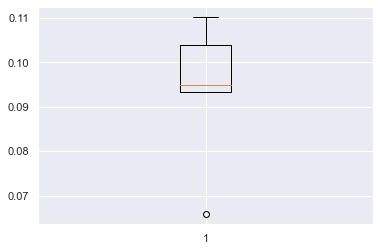

```python
scoring='recall'
kfold=StratifiedKFold(n_splits=5,shuffle=True,random_state=1)
cv_result_bfr=cross_val_score(estimator=lr, X=X_train, y=y_train, scoring=scoring, cv=kfold)

plt.boxplot(cv_result_bfr)
plt.show()
```

Performance on training set varies between 0.09 and 0.11 recall.

```
Accuracy on training set :  0.9192493157826144
Accuracy on test set :  0.919357781426747
Recall on training set :  0.08690330477356181
Recall on test set :  0.085
Precision on training set :  0.7135678391959799
Precision on test set :  0.725609756097561
```

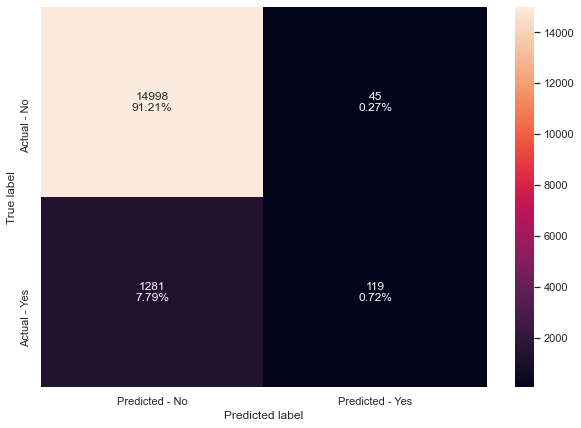

```python
scores_LR = get_metrics_score(lr,X_train,X_test,y_train,y_test)

make_confusion_matrix(lr,y_test)
```

```
Accuracy on training set :  0.9192493157826144
Accuracy on test set :  0.919357781426747
Recall on training set :  0.08690330477356181
Recall on test set :  0.085
Precision on training set :  0.7135678391959799
Precision on test set :  0.725609756097561
```

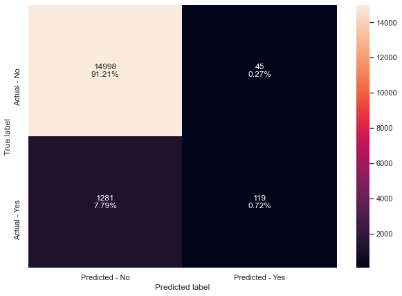

```python
scores_LR = get_metrics_score(lr,X_train,X_test,y_train,y_test)

make_confusion_matrix(lr,y_test)
```

Logistic regression have given similar performance on test and training. Poor recall.

# SMOTE OVERSAMPLING TRAINING DATA

```python
from imblearn.over_sampling import SMOTE
```

```python
print("Before UpSampling, counts of label 'Yes': {}".format(sum(y_train==1)))
print("Before UpSampling, counts of label 'No': {} \n".format(sum(y_train==0)))

sm = SMOTE(sampling_strategy = 1 ,k_neighbors = 5, random_state=1)   #Synthetic Minority Over Sampling Technique
X_train_over, y_train_over = sm.fit_resample(X_train, y_train)


print("After UpSampling, counts of label 'Yes': {}".format(sum(y_train_over==1)))
print("After UpSampling, counts of label 'No': {} \n".format(sum(y_train_over==0)))


print('After UpSampling, the shape of train_X: {}'.format(X_train_over.shape))
print('After UpSampling, the shape of train_y: {} \n'.format(y_train_over.shape))
```

```
Before UpSampling, counts of label 'Yes': 3268
Before UpSampling, counts of label 'No': 35097

After UpSampling, counts of label 'Yes': 35097
After UpSampling, counts of label 'No': 35097

After UpSampling, the shape of train_X: (70194, 19)
After UpSampling, the shape of train_y: (70194,)
```

# LOGISTIC REGRESSION ON OVERSAMPLED DATA

```python
log_reg_over = LogisticRegression(random_state = 1)

log_reg_over.fit(X_train_over,y_train_over)
```

```
LogisticRegression(random_state=1)
```

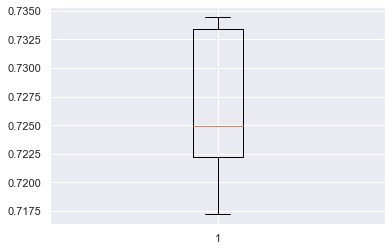

```python
scoring='recall'
kfold=StratifiedKFold(n_splits=5,shuffle=True,random_state=1)
cv_result_over=cross_val_score(estimator=log_reg_over, X=X_train_over, y=y_train_over, scoring=scoring, cv=kfold)

plt.boxplot(cv_result_over)
plt.show()
```

Training set performance .71 to .73. Improved performance.

```
Accuracy on training set :  0.7565318973131606
Accuracy on test set :  0.7597761965578057
Recall on training set :  0.7247628002393367
Recall on test set :  0.44285714285714284
Precision on training set :  0.7739373840021907
Precision on test set :  0.16358839050131926
```

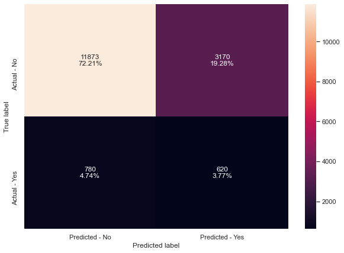

```python
get_metrics_score(log_reg_over,X_train_over,X_test,y_train_over,y_test)

make_confusion_matrix(log_reg_over,y_test)
```

Better performance on test set.

# REGULARIZATION

```python
lr_estimator = LogisticRegression(random_state=1,solver='saga')

# Grid of parameters to choose from
parameters = {'C': np.arange(0.1,1.1,0.1)}

# Run the grid search
grid_obj = GridSearchCV(lr_estimator, parameters, scoring='recall')
grid_obj = grid_obj.fit(X_train_over, y_train_over)

# Set the clf to the best combination of parameters
lr_estimator = grid_obj.best_estimator_

# Fit the best algorithm to the data.
lr_estimator.fit(X_train_over, y_train_over)
```

```
LogisticRegression(C=0.1, random_state=1, solver='saga')
```

```
Accuracy on training set :  0.761347123685785
Accuracy on test set :  0.7580125281274707
Recall on training set :  0.7384106903723965
Recall on test set :  0.45285714285714285
Precision on training set :  0.7739122644608355
Precision on test set :  0.16480374317650118
```

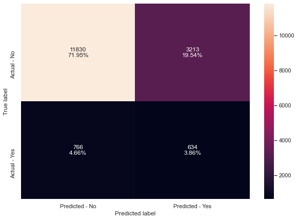

```python
get_metrics_score(lr_estimator,X_train_over,X_test,y_train_over,y_test)

# creating confusion matrix
make_confusion_matrix(lr_estimator,y_test)
```

Recall has improved. Large difference on training set and test set recall.

# UNDERSAMPLING

```python
from imblearn.under_sampling import RandomUnderSampler
rus = RandomUnderSampler(random_state = 1)
X_train_un, y_train_un = rus.fit_resample(X_train, y_train)
```

```python
print("Before Under Sampling, counts of label 'Yes': {}".format(sum(y_train==1)))
print("Before Under Sampling, counts of label 'No': {} \n".format(sum(y_train==0)))

print("After Under Sampling, counts of label 'Yes': {}".format(sum(y_train_un==1)))
print("After Under Sampling, counts of label 'No': {} \n".format(sum(y_train_un==0)))

print('After Under Sampling, the shape of train_X: {}'.format(X_train_un.shape))
print('After Under Sampling, the shape of train_y: {} \n'.format(y_train_un.shape))
```

```
Before Under Sampling, counts of label 'Yes': 3268
Before Under Sampling, counts of label 'No': 35097

After Under Sampling, counts of label 'Yes': 3268
After Under Sampling, counts of label 'No': 3268

After Under Sampling, the shape of train_X: (6536, 19)
After Under Sampling, the shape of train_y: (6536,)
```

# LOGISTIC REGRESSION ON UNDERSAMPLED DATA

```python
log_reg_under = LogisticRegression(random_state = 1)
log_reg_under.fit(X_train_un,y_train_un )
```

```
LogisticRegression(random_state=1)
```

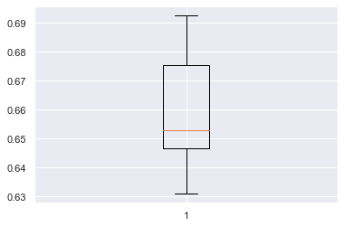

```python
scoring='recall'
kfold=StratifiedKFold(n_splits=5,shuffle=True,random_state=1)     #Setting number of splits equal to 5
cv_result_under=cross_val_score(estimator=log_reg_under, X=X_train_un, y=y_train_un, scoring=scoring, cv=kfold)
#Plotting boxplots for CV scores of model defined above
plt.boxplot(cv_result_under)
plt.show()
```

Performance on training set varies from .63 to .69. Lower performance than oversampling.

```
Accuracy on training set :  0.6773255813953488
Accuracy on test set :  0.699324940704251
Recall on training set :  0.6603427172582619
Recall on test set :  0.6557142857142857
Precision on training set :  0.6835603420969275
Precision on test set :  0.17063197026022306
```

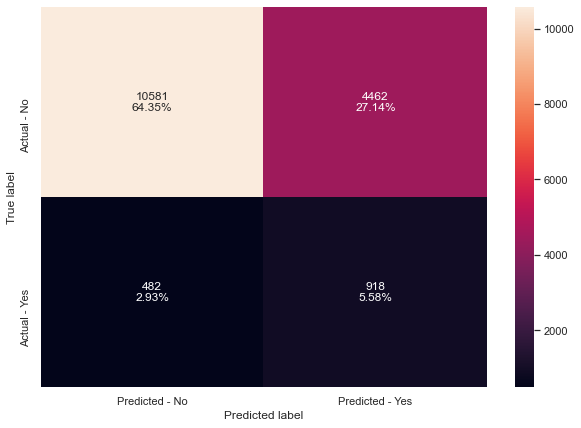

```python
get_metrics_score(log_reg_under,X_train_un,X_test,y_train_un,y_test)


# creating confusion matrix
make_confusion_matrix(log_reg_under,y_test)
```

Lower recall on training set, but more generalized perforance on test and training sets.

```python
models = []  # Empty list to store all the models

# Appending pipelines for each model into the list

models.append(
    (
        "DTREE",
        Pipeline(
            steps=[
                ("scaler", StandardScaler()),
                ("decision_tree", DecisionTreeClassifier(random_state=1,)),
            ]
        ),
    )
)


models.append(
    (
        "Bagging",
        Pipeline(
            steps=[
                ("scaler", StandardScaler()),
                ("random_forest", BaggingClassifier(random_state=1)),
            ]
        ),
    )
)


models.append(
    (
        "RF",
        Pipeline(
            steps=[
                ("scaler", StandardScaler()),
                ("random_forest", RandomForestClassifier(random_state=1)),
            ]
        ),
    )
)

models.append(
    (
        "ADB",
        Pipeline(
            steps=[
                ("scaler", StandardScaler()),
                ("adaboost", AdaBoostClassifier(random_state=1)),
            ]
        ),
    )
)


models.append(
    (
        "GBM",
        Pipeline(
            steps=[
                ("scaler", StandardScaler()),
                ("gradient_boosting", GradientBoostingClassifier(random_state=1)),
            ]
        ),
    )
)


models.append(
    (
        "XGB",
        Pipeline(
            steps=[
                ("scaler", StandardScaler()),
                ("xgboost", XGBClassifier(random_state=1,eval_metric='logloss')),
            ]
        ),
    )
)

results = []  # Empty list to store all model's CV scores
names = []  # Empty list to store name of the models

# loop through all models to get the mean cross validated score
for name, model in models:
    scoring = "recall"
    kfold = StratifiedKFold(
        n_splits=5, shuffle=True, random_state=1
    )  # Setting number of splits equal to 5
    cv_result = cross_val_score(
        estimator=model, X=X_train, y=y_train, scoring=scoring, cv=kfold
    )
    results.append(cv_result)
    names.append(name)
    print("{}: {}".format(name, cv_result.mean() * 100))
```

```
DTREE: 38.035976040949556
Bagging: 32.344109286239465
RF: 29.345668778772172
ADB: 15.943118329422893
GBM: 29.284085214793166
XGB: 32.68087537640905
```

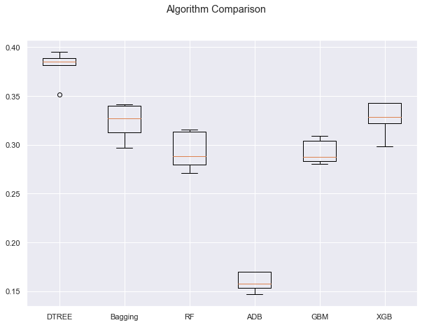

```python
# Plotting boxplots for CV scores of all models defined above
fig = plt.figure(figsize=(10, 7))

fig.suptitle("Algorithm Comparison")
ax = fig.add_subplot(111)

plt.boxplot(results)
ax.set_xticklabels(names)

plt.show()
```

# HYPERPARAMETER TUNING DTREE

```python
%%time

# Creating pipeline
pipe = make_pipeline(StandardScaler(), DecisionTreeClassifier(random_state=1))

# Parameter grid to pass in GridSearchCV

param_grid = {'decisiontreeclassifier__max_depth': np.arange(2,30),
              'decisiontreeclassifier__min_samples_leaf': [1, 2, 5, 7, 10],
              'decisiontreeclassifier__max_leaf_nodes' : [2, 3, 5, 10,15],
              'decisiontreeclassifier__min_impurity_decrease': [0.0001,0.001,0.01,0.1]
             }

# Type of scoring used to compare parameter combinations
scorer = metrics.make_scorer(metrics.recall_score)

# Calling GridSearchCV
grid_cv = GridSearchCV(estimator=pipe, param_grid=param_grid, scoring=scorer, cv=5, n_jobs = -1)

# Fitting parameters in GridSeachCV
grid_cv.fit(X_train, y_train)

print(
    "Best Parameters:{} \nScore: {}".format(grid_cv.best_params_, grid_cv.best_score_)
)
```

```
Best Parameters:{'decisiontreeclassifier__max_depth': 7, 'decisiontreeclassifier__max_leaf_nodes': 15, 'decisiontreeclassifier__min_impurity_decrease': 0.0001, 'decisiontreeclassifier__min_samples_leaf': 10}
Score: 0.1930834398752406
Wall time: 3min 19s
```

```python
# Creating new pipeline with best parameters
dtree_tuned1 = make_pipeline(
    StandardScaler(),
    DecisionTreeClassifier(
        max_depth=7,
        max_leaf_nodes=15,
        random_state=1,
        min_impurity_decrease=0.0001,
        min_samples_leaf=10
    ),
)

# Fit the model on training data
dtree_tuned1.fit(X_train, y_train)
```

```
Pipeline(steps=[('standardscaler', StandardScaler()),
                ('decisiontreeclassifier',
                 DecisionTreeClassifier(max_depth=7, max_leaf_nodes=15,
                                        min_impurity_decrease=0.0001,
                                        min_samples_leaf=10, random_state=1))])
```

```
Accuracy on training set :  0.9300925322559624
Accuracy on test set :  0.9289059174116645
Recall on training set :  0.2004283965728274
Recall on test set :  0.19214285714285714
Precision on training set :  0.9046961325966851
Precision on test set :  0.8762214983713354
```

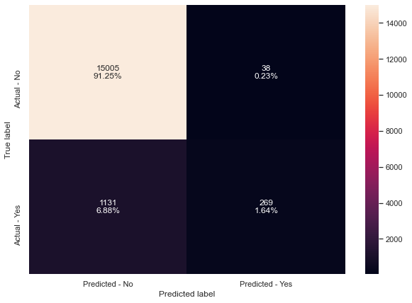

```python
# Calculating different metrics
get_metrics_score(dtree_tuned1,X_train,X_test,y_train,y_test)

# Creating confusion matrix
make_confusion_matrix(dtree_tuned1, y_test)
```

Recall has decreased on test and training sets.

```python
%%time

# Creating pipeline
pipe = make_pipeline(StandardScaler(), DecisionTreeClassifier(random_state=1))

# Parameter grid to pass in RandomSearchCV
param_grid = {'decisiontreeclassifier__max_depth': np.arange(2,30),
              'decisiontreeclassifier__min_samples_leaf': [1, 2, 5, 7, 10],
              'decisiontreeclassifier__max_leaf_nodes' : [2, 3, 5, 10,15],
              'decisiontreeclassifier__min_impurity_decrease': [0.0001,0.001,0.01,0.1]
             }

# Type of scoring used to compare parameter combinations
scorer = metrics.make_scorer(metrics.recall_score)

#Calling RandomizedSearchCV
randomized_cv = RandomizedSearchCV(estimator=pipe, param_distributions=param_grid, n_jobs = -1, n_iter=50, scoring=scorer, cv=5, random_state=1)

#Fitting parameters in RandomizedSearchCV
randomized_cv.fit(X_train,y_train)

print("Best parameters are {} with CV score={}:" .format(randomized_cv.best_params_,randomized_cv.best_score_))
```

```
Best parameters are {'decisiontreeclassifier__min_samples_leaf': 2, 'decisiontreeclassifier__min_impurity_decrease': 0.0001, 'decisiontreeclassifier__max_leaf_nodes': 15, 'decisiontreeclassifier__max_depth': 6} with CV score=0.18696770024024614:
Wall time: 7.84 s
```

```python
# Creating new pipeline with best parameters
dtree_tuned2 = make_pipeline(
    StandardScaler(),
    DecisionTreeClassifier(
        max_depth=6,
        max_leaf_nodes=15,
        random_state=1,
        min_impurity_decrease=0.001,
        min_samples_leaf=2
    ),
)

# Fit the model on training data
dtree_tuned2.fit(X_train, y_train)
```

```
Pipeline(steps=[('standardscaler', StandardScaler()),
                ('decisiontreeclassifier',
                 DecisionTreeClassifier(max_depth=6, max_leaf_nodes=15,
                                        min_impurity_decrease=0.001,
                                        min_samples_leaf=2, random_state=1))])
```

```
Accuracy on training set :  0.9228202789000391
Accuracy on test set :  0.9227634859818767
Recall on training set :  0.10862913096695226
Recall on test set :  0.10928571428571429
Precision on training set :  0.8808933002481389
Precision on test set :  0.8693181818181818
```

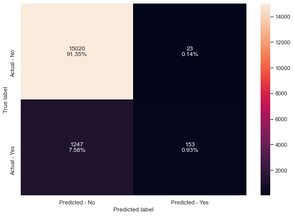

```python
# Calculating different metrics
get_metrics_score(dtree_tuned2,X_train,X_test,y_train,y_test)

# Creating confusion matrix
make_confusion_matrix(dtree_tuned2, y_test)
```

Recall has decreased on test and training sets.

# HYPERPARAMETER TUNING FOR BAGGING

```python
%%time

# Creating pipeline
pipe = make_pipeline(StandardScaler(), BaggingClassifier(random_state=1))

# Parameter grid to pass in GridSearchCV

param_grid = {
              'baggingclassifier__max_samples': [0.7,0.8,0.9,1],
              'baggingclassifier__max_features': [0.7,0.8,0.9,1],
              'baggingclassifier__n_estimators' : [10,20,30,40,50],
             }

# Type of scoring used to compare parameter combinations
scorer = metrics.make_scorer(metrics.recall_score)

# Calling GridSearchCV
grid_cv = GridSearchCV(estimator=pipe, param_grid=param_grid, scoring=scorer, cv=5, n_jobs = -1)

# Fitting parameters in GridSeachCV
grid_cv.fit(X_train, y_train)

print(
    "Best Parameters:{} \nScore: {}".format(grid_cv.best_params_, grid_cv.best_score_)
)
```

```
Best Parameters:{'baggingclassifier__max_features': 0.9, 'baggingclassifier__max_samples': 0.9, 'baggingclassifier__n_estimators': 40}
Score: 0.32221223147927
Wall time: 1min 33s
```

```python
# Creating new pipeline with best parameters
bagg_tuned1 = make_pipeline(
    StandardScaler(),
    BaggingClassifier(
        max_features=0.9,
        max_samples=0.9,
        random_state=1,
        n_estimators=40,
    ),
)

# Fit the model on training data
bagg_tuned1.fit(X_train, y_train)
```

```
Pipeline(steps=[('standardscaler', StandardScaler()),
                ('baggingclassifier',
                 BaggingClassifier(max_features=0.9, max_samples=0.9,
                                   n_estimators=40, random_state=1))])
```

```
Accuracy on training set :  0.9954646161866284
Accuracy on test set :  0.9371160980356382
Recall on training set :  0.9479804161566707
Recall on test set :  0.32785714285714285
Precision on training set :  0.9987105093488072
Precision on test set :  0.8315217391304348
```

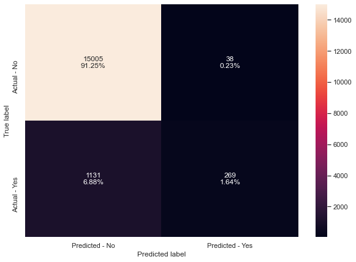

```python
# Calculating different metrics
get_metrics_score(bagg_tuned1,X_train,X_test,y_train,y_test)

# Creating confusion matrix
make_confusion_matrix(dtree_tuned1, y_test)
```

Training set recall is improved. Recall on test set slightly improved.

# RANDOMIZED GRIDSEARCH CV

```python
%%time

# Creating pipeline
pipe = make_pipeline(StandardScaler(), BaggingClassifier(random_state=1))

# Parameter grid to pass in RandomSearchCV
param_grid = {
              'baggingclassifier__max_samples': [0.7,0.8,0.9,1],
              'baggingclassifier__max_features': [0.7,0.8,0.9,1],
              'baggingclassifier__n_estimators' : [10,20,30,40,50],
             }

# Type of scoring used to compare parameter combinations
scorer = metrics.make_scorer(metrics.recall_score)

#Calling RandomizedSearchCV
randomized_cv = RandomizedSearchCV(estimator=pipe, param_distributions=param_grid, n_jobs = -1, n_iter=50, scoring=scorer, cv=5, random_state=1)

#Fitting parameters in RandomizedSearchCV
randomized_cv.fit(X_train,y_train)

print("Best parameters are {} with CV score={}:" .format(randomized_cv.best_params_,randomized_cv.best_score_))
```

```
Best parameters are {'baggingclassifier__n_estimators': 40, 'baggingclassifier__max_samples': 0.9, 'baggingclassifier__max_features': 0.9} with CV score=0.32221223147927:
Wall time: 1min 2s
```

```python
# Creating new pipeline with best parameters
bagg_tuned2 = make_pipeline(
    StandardScaler(),
    BaggingClassifier(
        max_features=0.9,
        random_state=1,
        max_samples=0.9,
        n_estimators=40
    ),
)

# Fit the model on training data
bagg_tuned2.fit(X_train, y_train)
```

```
Pipeline(steps=[('standardscaler', StandardScaler()),
                ('baggingclassifier',
                 BaggingClassifier(max_features=0.9, max_samples=0.9,
                                   n_estimators=40, random_state=1))])
```

```
Accuracy on training set :  0.9954646161866284
Accuracy on test set :  0.9371160980356382
Recall on training set :  0.9479804161566707
Recall on test set :  0.32785714285714285
Precision on training set :  0.9987105093488072
Precision on test set :  0.8315217391304348
```

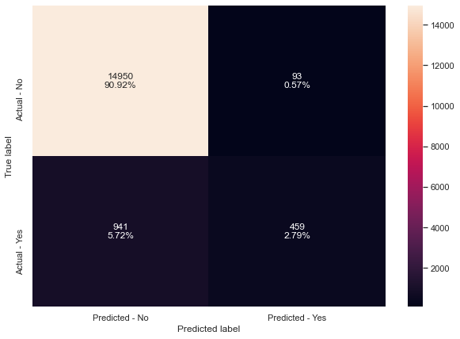

```python
# Calculating different metrics
get_metrics_score(bagg_tuned2,X_train,X_test,y_train,y_test)

# Creating confusion matrix
make_confusion_matrix(bagg_tuned2, y_test)
```

# HYPERPARAMETER TUNING RANDOM FOREST

```python
%%time

# Creating pipeline
pipe = make_pipeline(StandardScaler(), RandomForestClassifier(random_state=1))

# Parameter grid to pass in GridSearchCV

param_grid = {
    "randomforestclassifier__n_estimators": [100,150,250],
    "randomforestclassifier__min_samples_leaf": np.arange(1, 6),
    "randomforestclassifier__max_features": [np.arange(0.3, 0.6, 0.1),'sqrt','log2'],
    "randomforestclassifier__max_samples": np.arange(0.2, 0.6, 0.1),
}

# Type of scoring used to compare parameter combinations
scorer = metrics.make_scorer(metrics.recall_score)

# Calling GridSearchCV
grid_cv = GridSearchCV(estimator=pipe, param_grid=param_grid, scoring=scorer, cv=5, n_jobs = -1)

# Fitting parameters in GridSeachCV
grid_cv.fit(X_train, y_train)

print(
    "Best Parameters:{} \nScore: {}".format(grid_cv.best_params_, grid_cv.best_score_)
)
```

```
Best Parameters:{'randomforestclassifier__max_features': 'sqrt', 'randomforestclassifier__max_samples': 0.5000000000000001, 'randomforestclassifier__min_samples_leaf': 1, 'randomforestclassifier__n_estimators': 100}
Score: 0.2790634615114433
Wall time: 5min 1s
```

```python
# Creating new pipeline with best parameters
rf_tuned1 = make_pipeline(
    StandardScaler(),
    RandomForestClassifier(
        n_estimators=100,
        max_features='sqrt',
        random_state=1,
        max_samples=0.5000000000000001,
        min_samples_leaf=1
    ),
)

# Fit the model on training data
rf_tuned1.fit(X_train, y_train)
```

```
Pipeline(steps=[('standardscaler', StandardScaler()),
                ('randomforestclassifier',
                 RandomForestClassifier(max_features='sqrt',
                                        max_samples=0.5000000000000001,
                                        random_state=1))])
```

```
Accuracy on training set :  0.9586602371953603
Accuracy on test set :  0.9370552818828681
Recall on training set :  0.5156058751529988
Recall on test set :  0.295
Precision on training set :  0.9982227488151659
Precision on test set :  0.89587852494577
```

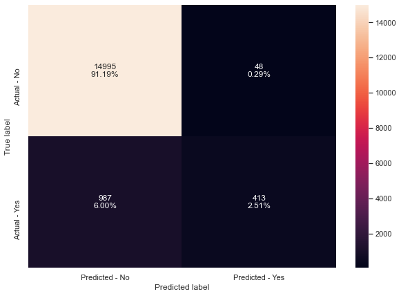

```python
# Calculating different metrics
get_metrics_score(rf_tuned1,X_train,X_test,y_train,y_test)

# Creating confusion matrix
make_confusion_matrix(rf_tuned1, y_test)
```

Recall on training set has dropped as well as test set.

# Randomized Gridsearch CV

```python
%%time

# Creating pipeline
pipe = make_pipeline(StandardScaler(), RandomForestClassifier(random_state=1))

# Parameter grid to pass in RandomSearchCV
param_grid = {
    "randomforestclassifier__n_estimators": [100,150,250],
    "randomforestclassifier__min_samples_leaf": np.arange(1, 6),
    "randomforestclassifier__max_features": [np.arange(0.3, 0.6, 0.1),'sqrt','log2'],
    "randomforestclassifier__max_samples": np.arange(0.2, 0.6, 0.1),
}

# Type of scoring used to compare parameter combinations
scorer = metrics.make_scorer(metrics.recall_score)

#Calling RandomizedSearchCV
randomized_cv = RandomizedSearchCV(estimator=pipe, param_distributions=param_grid, n_jobs = -1, n_iter=50, scoring=scorer, cv=5, random_state=1)

#Fitting parameters in RandomizedSearchCV
randomized_cv.fit(X_train,y_train)

print("Best parameters are {} with CV score={}:" .format(randomized_cv.best_params_,randomized_cv.best_score_))
```

```
Best parameters are {'randomforestclassifier__n_estimators': 250, 'randomforestclassifier__min_samples_leaf': 1, 'randomforestclassifier__max_samples': 0.5000000000000001, 'randomforestclassifier__max_features': 'sqrt'} with CV score=0.2778406882373051:
Wall time: 1min 23s
```

```python
# Creating new pipeline with best parameters
rf_tuned2 = make_pipeline(
    StandardScaler(),
    RandomForestClassifier(
        n_estimators=250,
        max_features='sqrt',
        random_state=1,
        max_samples=0.5000000000000001,
        min_samples_leaf=1
    ),
)

# Fit the model on training data
rf_tuned2.fit(X_train, y_train)
```

```
Pipeline(steps=[('standardscaler', StandardScaler()),
                ('randomforestclassifier',
                 RandomForestClassifier(max_features='sqrt',
                                        max_samples=0.5000000000000001,
                                        n_estimators=250, random_state=1))])
```

```
Accuracy on training set :  0.957643685650984
Accuracy on test set :  0.9372377303411786
Recall on training set :  0.5033659730722154
Recall on test set :  0.2978571428571429
Precision on training set :  0.9987856709168185
Precision on test set :  0.8948497854077253
```

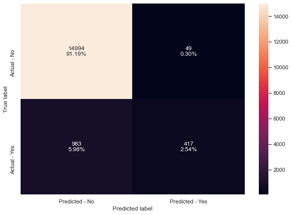

```python
# Calculating different metrics
get_metrics_score(rf_tuned2,X_train,X_test,y_train,y_test)

# Creating confusion matrix
make_confusion_matrix(rf_tuned2, y_test)
```

No changes in Recall on Training or Test Sets.

# HYPERPARAMETER TUNING ADABOOST

# GridSearchCV

```python
%%time

# Creating pipeline
pipe = make_pipeline(StandardScaler(), AdaBoostClassifier(random_state=1))

# Parameter grid to pass in GridSearchCV
param_grid = {
    "adaboostclassifier__n_estimators": np.arange(10, 110, 10),
    "adaboostclassifier__learning_rate": [0.1, 0.01, 0.2, 0.05, 1],
    "adaboostclassifier__base_estimator": [
        DecisionTreeClassifier(max_depth=1, random_state=1),
        DecisionTreeClassifier(max_depth=2, random_state=1),
        DecisionTreeClassifier(max_depth=3, random_state=1),
    ],
}

# Type of scoring used to compare parameter combinations
scorer = metrics.make_scorer(metrics.recall_score)

# Calling GridSearchCV
grid_cv = GridSearchCV(estimator=pipe, param_grid=param_grid, scoring=scorer, cv=5, n_jobs = -1)

# Fitting parameters in GridSeachCV
grid_cv.fit(X_train, y_train)

print(
    "Best Parameters:{} \nScore: {}".format(grid_cv.best_params_, grid_cv.best_score_)
)
```

```
Best Parameters:{'adaboostclassifier__base_estimator': DecisionTreeClassifier(max_depth=3, random_state=1), 'adaboostclassifier__learning_rate': 1, 'adaboostclassifier__n_estimators': 100}
Score: 0.3271070711044298
Wall time: 4min 23s
```

```python
# Creating new pipeline with best parameters
abc_tuned1 = make_pipeline(
    StandardScaler(),
    AdaBoostClassifier(
        base_estimator=DecisionTreeClassifier(max_depth=3, random_state=1),
        n_estimators=100,
        learning_rate=1,
        random_state=1,
    ),
)

# Fit the model on training data
abc_tuned1.fit(X_train, y_train)
```

```
Pipeline(steps=[('standardscaler', StandardScaler()),
                ('adaboostclassifier',
                 AdaBoostClassifier(base_estimator=DecisionTreeClassifier(max_depth=3,
                                                                          random_state=1),
                                    learning_rate=1, n_estimators=100,
                                    random_state=1))])
```

```
Accuracy on training set :  0.9415091880620358
Accuracy on test set :  0.9372985464939488
Recall on training set :  0.35893512851897186
Recall on test set :  0.3364285714285714
Precision on training set :  0.8872919818456884
Precision on test set :  0.8219895287958116
```

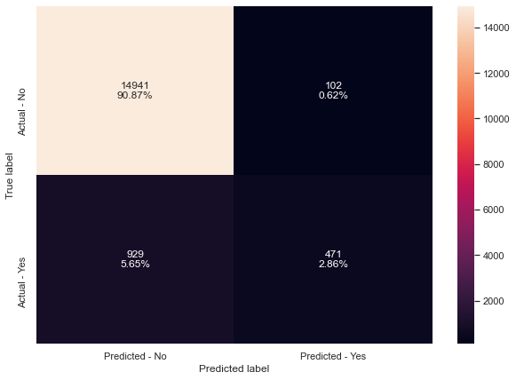

```python
# Calculating different metrics
get_metrics_score(abc_tuned1,X_train,X_test,y_train,y_test)

# Creating confusion matrix
make_confusion_matrix(abc_tuned1, y_test)
```

# RandomizedSearchCV

```python
%%time

# Creating pipeline
pipe = make_pipeline(StandardScaler(), AdaBoostClassifier(random_state=1))

# Parameter grid to pass in RandomSearchCV
param_grid = {
    "adaboostclassifier__n_estimators": np.arange(10, 110, 10),
    "adaboostclassifier__learning_rate": [0.1, 0.01, 0.2, 0.05, 1],
    "adaboostclassifier__base_estimator": [
        DecisionTreeClassifier(max_depth=1, random_state=1),
        DecisionTreeClassifier(max_depth=2, random_state=1),
        DecisionTreeClassifier(max_depth=3, random_state=1),
    ],
}
# Type of scoring used to compare parameter combinations
scorer = metrics.make_scorer(metrics.recall_score)

#Calling RandomizedSearchCV
randomized_cv = RandomizedSearchCV(estimator=pipe, param_distributions=param_grid, n_jobs = -1, n_iter=50, scoring=scorer, cv=5, random_state=1)

#Fitting parameters in RandomizedSearchCV
randomized_cv.fit(X_train,y_train)

print("Best parameters are {} with CV score={}:" .format(randomized_cv.best_params_,randomized_cv.best_score_))
```

```
Best parameters are {'adaboostclassifier__n_estimators': 70, 'adaboostclassifier__learning_rate': 1, 'adaboostclassifier__base_estimator': DecisionTreeClassifier(max_depth=3, random_state=1)} with CV score=0.321600610684163:
Wall time: 1min 37s
```

```python
# Creating new pipeline with best parameters
abc_tuned2 = make_pipeline(
    StandardScaler(),
    AdaBoostClassifier(
        base_estimator=DecisionTreeClassifier(max_depth=3, random_state=1),
        n_estimators=70,
        learning_rate=1,
        random_state=1,
    ),
)

# Fit the model on training data
abc_tuned2.fit(X_train, y_train)
```

```
Pipeline(steps=[('standardscaler', StandardScaler()),
                ('adaboostclassifier',
                 AdaBoostClassifier(base_estimator=DecisionTreeClassifier(max_depth=3,
                                                                          random_state=1),
                                    learning_rate=1, n_estimators=70,
                                    random_state=1))])
```

```
Accuracy on training set :  0.9399713280333637
Accuracy on test set :  0.9379675241744208
Recall on training set :  0.34577723378212977
Recall on test set :  0.3364285714285714
Precision on training set :  0.8725868725868726
Precision on test set :  0.8380782918149466
```

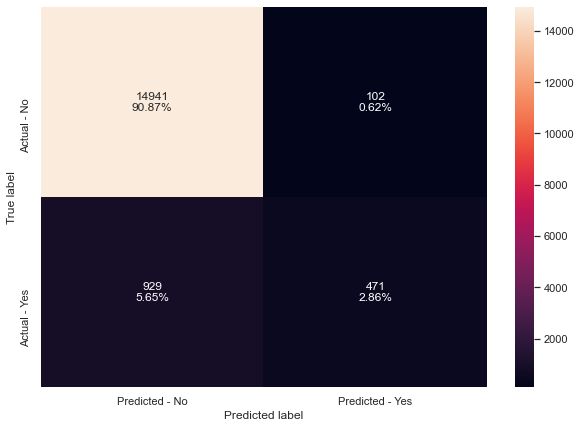

```python
# Calculating different metrics
get_metrics_score(abc_tuned2,X_train,X_test,y_train,y_test)

# Creating confusion matrix
make_confusion_matrix(abc_tuned1, y_test)
```

Very little change in recall on test and training sets.

# Hyperparameter tuning GradientBoosting

# GridSearchCV

```python
%%time

# Creating pipeline
pipe = make_pipeline(StandardScaler(), GradientBoostingClassifier(random_state=1))

# Parameter grid to pass in GridSearchCV
param_grid = {
    "gradientboostingclassifier__init": [AdaBoostClassifier(random_state=1),DecisionTreeClassifier(random_state=1)],
    "gradientboostingclassifier__n_estimators": np.arange(75,150,25),
    "gradientboostingclassifier__learning_rate": [0.1, 0.01, 0.2, 0.05, 1],
    "gradientboostingclassifier__subsample":[0.5,0.7,1],
    "gradientboostingclassifier__max_features":[0.5,0.7,1],
}

# Type of scoring used to compare parameter combinations
scorer = metrics.make_scorer(metrics.recall_score)

# Calling GridSearchCV
grid_cv = GridSearchCV(estimator=pipe, param_grid=param_grid, scoring=scorer, cv=5, n_jobs = -1)

# Fitting parameters in GridSeachCV
grid_cv.fit(X_train, y_train)

print(
    "Best Parameters:{} \nScore: {}".format(grid_cv.best_params_, grid_cv.best_score_)
)
```

```
Best Parameters:{'gradientboostingclassifier__init': DecisionTreeClassifier(random_state=1), 'gradientboostingclassifier__learning_rate': 1, 'gradientboostingclassifier__max_features': 0.5, 'gradientboostingclassifier__n_estimators': 75, 'gradientboostingclassifier__subsample': 0.5}
Score: 0.7778584842481888
Wall time: 9min 48s
```

```python
# Creating new pipeline with best parameters
gbc_tuned1 = make_pipeline(
    StandardScaler(),
    GradientBoostingClassifier(
        init=AdaBoostClassifier(random_state=1),
        learning_rate=1,
        max_features=0.5,
        n_estimators=75,
        subsample=0.5,
        random_state=1,
    ),
)

# Fit the model on training data
gbc_tuned1.fit(X_train, y_train)
```

```
Pipeline(steps=[('standardscaler', StandardScaler()),
                ('gradientboostingclassifier',
                 GradientBoostingClassifier(init=AdaBoostClassifier(random_state=1),
                                            learning_rate=1, max_features=0.5,
                                            n_estimators=75, random_state=1,
                                            subsample=0.5))])
```

```
Accuracy on training set :  0.9376254398540336
Accuracy on test set :  0.9347442680776014
Recall on training set :  0.34516523867809057
Recall on test set :  0.3435714285714286
Precision on training set :  0.8167994207096307
Precision on test set :  0.75748031496063
```

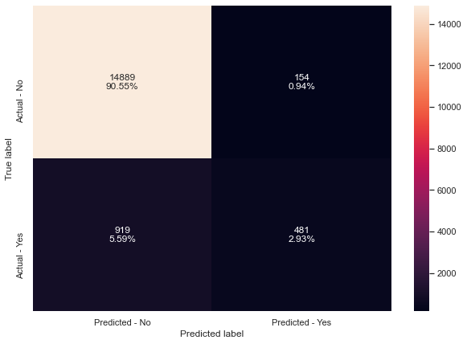

```python
# Calculating different metrics
get_metrics_score(gbc_tuned1,X_train,X_test,y_train,y_test)

# Creating confusion matrix
make_confusion_matrix(gbc_tuned1, y_test)
```

Test and Training set recall .34

# RandomizedSearchCV

```python
%%time

#Creating pipeline
pipe=make_pipeline(StandardScaler(),GradientBoostingClassifier(random_state=1))

#Parameter grid to pass in RandomSearchCV
param_grid = {
    "gradientboostingclassifier__init": [AdaBoostClassifier(random_state=1),DecisionTreeClassifier(random_state=1)],
    "gradientboostingclassifier__n_estimators": np.arange(75,150,25),
    "gradientboostingclassifier__learning_rate": [0.1, 0.01, 0.2, 0.05, 1],
    "gradientboostingclassifier__subsample":[0.5,0.7,1],
    "gradientboostingclassifier__max_features":[0.5,0.7,1],
}

# Type of scoring used to compare parameter combinations
scorer = metrics.make_scorer(metrics.recall_score)

#Calling RandomizedSearchCV
randomized_cv = RandomizedSearchCV(estimator=pipe, param_distributions=param_grid, n_iter=50, scoring=scorer, cv=5, random_state=1, n_jobs = -1)

#Fitting parameters in RandomizedSearchCV
randomized_cv.fit(X_train,y_train)

print("Best parameters are {} with CV score={}:" .format(randomized_cv.best_params_,randomized_cv.best_score_))
```

[output not shown]

```python
# Creating new pipeline with best parameters
gbc_tuned2 = make_pipeline(
    StandardScaler(),
    GradientBoostingClassifier(
        init=AdaBoostClassifier(random_state=1),
        learning_rate=1,
        max_features=0.5,
        n_estimators=100,
        subsample=0.5,
        random_state=1,
    ),
)

# Fit the model on training data
gbc_tuned2.fit(X_train, y_train)
```

```
Pipeline(steps=[('standardscaler', StandardScaler()),
                ('gradientboostingclassifier',
                 GradientBoostingClassifier(init=AdaBoostClassifier(random_state=1),
                                            learning_rate=1, max_features=0.5,
                                            random_state=1, subsample=0.5))])
```

```
Accuracy on training set :  0.9373126547634563
Accuracy on test set :  0.9341969227026699
Recall on training set :  0.3445532435740514
Recall on test set :  0.34285714285714286
Precision on training set :  0.8106551475881929
Precision on test set :  0.7476635514018691
```

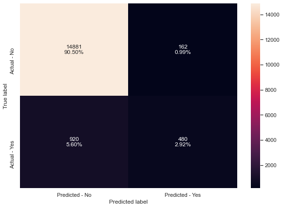

```python
# Calculating different metrics
get_metrics_score(gbc_tuned2,X_train,X_test,y_train,y_test)

# Creating confusion matrix
make_confusion_matrix(gbc_tuned2, y_test)
```

No changes in recall.

# Hyperparameter Tuning XGBoost

# GridSearchCV

```python
%%time

#Creating pipeline
pipe=make_pipeline(StandardScaler(), XGBClassifier(random_state=1,eval_metric='logloss'))

#Parameter grid to pass in GridSearchCV
param_grid={'xgbclassifier__n_estimators':np.arange(50,300,50),'xgbclassifier__scale_pos_weight':[0,1,2,5,10],
            'xgbclassifier__learning_rate':[0.01,0.1,0.2,0.05], 'xgbclassifier__gamma':[0,1,3,5],
            'xgbclassifier__subsample':[0.7,0.8,0.9,1]}

# Type of scoring used to compare parameter combinations
scorer = metrics.make_scorer(metrics.recall_score)

#Calling GridSearchCV
grid_cv = GridSearchCV(estimator=pipe, param_grid=param_grid, scoring=scorer, cv=5, n_jobs = -1)

#Fitting parameters in GridSeachCV
grid_cv.fit(X_train,y_train)


print("Best parameters are {} with CV score={}:" .format(grid_cv.best_params_,grid_cv.best_score_))
```

```
Best parameters are {'xgbclassifier__gamma': 0, 'xgbclassifier__learning_rate': 0.2, 'xgbclassifier__n_estimators': 50, 'xgbclassifier__scale_pos_weight': 10, 'xgbclassifier__subsample': 0.8} with CV score=0.5905676459155813:
Wall time: 3h 16min 31s
```

```python
# Creating new pipeline with best parameters
xgb_tuned1 = make_pipeline(
    StandardScaler(),
    XGBClassifier(
        random_state=1,
        n_estimators=50,
        scale_pos_weight=10,
        subsample=0.8,
        learning_rate=0.2,
        gamma=0,
        eval_metric='logloss',
    ),
)

# Fit the model on training data
xgb_tuned1.fit(X_train, y_train)
```

```
Pipeline(steps=[('standardscaler', StandardScaler()),
                ('xgbclassifier',
                 XGBClassifier(base_score=0.5, booster='gbtree',
                               colsample_bylevel=1, colsample_bynode=1,
                               colsample_bytree=1, eval_metric='logloss',
                               gamma=0, gpu_id=-1, importance_type='gain',
                               interaction_constraints='', learning_rate=0.2,
                               max_delta_step=0, max_depth=6,
                               min_child_weight=1, missing=nan,
                               monotone_constraints='()', n_estimators=50,
                               n_jobs=8, num_parallel_tree=1, random_state=1,
                               reg_alpha=0, reg_lambda=1, scale_pos_weight=10,
                               subsample=0.8, tree_method='exact',
                               validate_parameters=1, verbosity=None))])
```

```
Accuracy on training set :  0.8591424475433338
Accuracy on test set :  0.8438849358389588
Recall on training set :  0.6967564259485924
Recall on test set :  0.5771428571428572
Precision on training set :  0.34035874439461883
Precision on test set :  0.29033417175709664
```

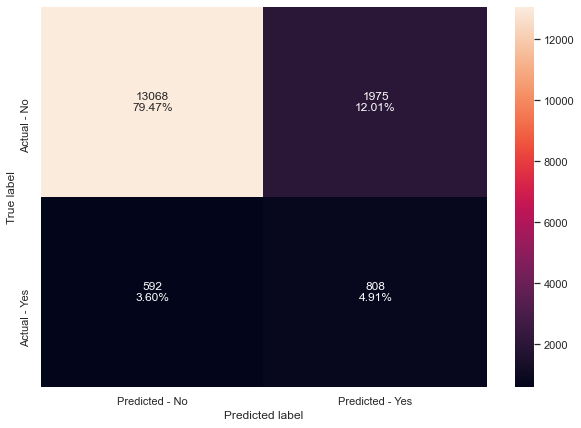

```python
# Calculating different metrics
get_metrics_score(xgb_tuned1,X_train,X_test,y_train,y_test)

# Creating confusion matrix
make_confusion_matrix(xgb_tuned1, y_test)
```

Recall on test and training sets have increased.

# RandomizedSearchCV

```python
%%time

#Creating pipeline
pipe=make_pipeline(StandardScaler(),XGBClassifier(random_state=1,eval_metric='logloss'))

#Parameter grid to pass in RandomSearchCV
param_grid={'xgbclassifier__n_estimators':np.arange(50,300,50),'xgbclassifier__scale_pos_weight':[0,1,2,5,10],
            'xgbclassifier__learning_rate':[0.01,0.1,0.2,0.05], 'xgbclassifier__gamma':[0,1,3,5],
            'xgbclassifier__subsample':[0.7,0.8,0.9,1]}

# Type of scoring used to compare parameter combinations
scorer = metrics.make_scorer(metrics.recall_score)

#Calling RandomizedSearchCV
randomized_cv = RandomizedSearchCV(estimator=pipe, param_distributions=param_grid, n_iter=50, n_jobs = -1, scoring=scorer, cv=5, random_state=1)

#Fitting parameters in RandomizedSearchCV
randomized_cv.fit(X_train,y_train)

print("Best parameters are {} with CV score={}:" .format(randomized_cv.best_params_,randomized_cv.best_score_))
```

```
Best parameters are {'xgbclassifier__subsample': 0.7, 'xgbclassifier__scale_pos_weight': 10, 'xgbclassifier__n_estimators': 50, 'xgbclassifier__learning_rate': 0.2, 'xgbclassifier__gamma': 5} with CV score=0.5813891191442929:
Wall time: 4min 59s
```

```python
# Creating new pipeline with best parameters
xgb_tuned2 = Pipeline(
    steps=[
        ("scaler", StandardScaler()),
        (
            "XGB",
            XGBClassifier(
                random_state=1,
                n_estimators=50,
                scale_pos_weight=10,
                learning_rate=0.2,
                gamma=5,
                subsample=0.7,
                eval_metric='logloss',
            ),
        ),
    ]
)
# Fit the model on training data
xgb_tuned2.fit(X_train, y_train)
```

```
Pipeline(steps=[('scaler', StandardScaler()),
                ('XGB',
                 XGBClassifier(base_score=0.5, booster='gbtree',
                               colsample_bylevel=1, colsample_bynode=1,
                               colsample_bytree=1, eval_metric='logloss',
                               gamma=5, gpu_id=-1, importance_type='gain',
                               interaction_constraints='', learning_rate=0.2,
                               max_delta_step=0, max_depth=6,
                               min_child_weight=1, missing=nan,
                               monotone_constraints='()', n_estimators=50,
                               n_jobs=8, num_parallel_tree=1, random_state=1,
                               reg_alpha=0, reg_lambda=1, scale_pos_weight=10,
                               subsample=0.7, tree_method='exact',
                               validate_parameters=1, verbosity=None))])
```

```
Accuracy on training set :  0.8583865502411052
Accuracy on test set :  0.8440673842972694
Recall on training set :  0.6866585067319462
Recall on test set :  0.5835714285714285
Precision on training set :  0.337291447467308
Precision on test set :  0.2919942816297355
```

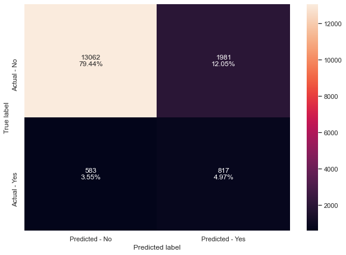

```python
# Calculating different metrics
get_metrics_score(xgb_tuned2,X_train,X_test,y_train,y_test)

# Creating confusion matrix
make_confusion_matrix(xgb_tuned2, y_test)
```

GridSearch took a very significant amount of time. Parameters for GridSearch and RandomSearch are similar. Generalized performance on training and test sets.

```python
# defining list of model
models = [lr]

# defining empty lists to add train and test results
acc_train = []
acc_test = []
recall_train = []
recall_test = []
precision_train = []
precision_test = []

# looping through all the models to get the metrics score - Accuracy, Recall and Precision
for model in models:

    j = get_metrics_score(model,X_train,X_test,y_train,y_test,False)
    acc_train.append(j[0])
    acc_test.append(j[1])
    recall_train.append(j[2])
    recall_test.append(j[3])
    precision_train.append(j[4])
    precision_test.append(j[5])
```

```python
# defining list of models
models = [log_reg_over, lr_estimator]

# looping through all the models to get the metrics score - Accuracy, Recall and Precision
for model in models:

    j = get_metrics_score(model,X_train_over,X_test,y_train_over,y_test,False)
    acc_train.append(j[0])
    acc_test.append(j[1])
    recall_train.append(j[2])
    recall_test.append(j[3])
    precision_train.append(j[4])
    precision_test.append(j[5])
```

```python
# defining list of model
models = [log_reg_under]

# looping through all the models to get the metrics score - Accuracy, Recall and Precision
for model in models:

    j = get_metrics_score(model,X_train_un,X_test,y_train_un,y_test,False)
    acc_train.append(j[0])
    acc_test.append(j[1])
    recall_train.append(j[2])
    recall_test.append(j[3])
    precision_train.append(j[4])
    precision_test.append(j[5])
```

```python
# defining list of models
models = [dtree_tuned1,dtree_tuned2,bagg_tuned1,bagg_tuned2,rf_tuned1,rf_tuned2,abc_tuned1,abc_tuned2,gbc_tuned1,gbc_tuned2,xgb_tuned1, xgb_tuned2]


# looping through all the models to get the metrics score - Accuracy, Recall and Precision
for model in models:

    j = get_metrics_score(model,X_train,X_test,y_train,y_test,False)
    acc_train.append(j[0])
    acc_test.append(j[1])
    recall_train.append(j[2])
    recall_test.append(j[3])
    precision_train.append(j[4])
    precision_test.append(j[5])
```

```python
comparison_frame = pd.DataFrame(
    {
        "Model": [
            "Logistic Regression",
            'Logistic Regression on Oversampled data',
            'Logistic Regression-Regularized (Oversampled data)',
            'Logistic Regression on Undersampled data',
            "Decision Tree with GridSearchCV",
            "Decision Tree with RandomizedSearchCV",
            "Bagging Classifier with GridSearchCV",
            "Bagging Classifier with RandomizedSearchCV",
            "Random Forest with GridSearchCV",
            "Random Forest with RandomizedSearchCV",
            "AdaBoost with GridSearchCV",
            "AdaBoost Tree with RandomizedSearchCV",
            "GradientBoost with GridSearchCV",
            "GradientBoost Tree with RandomizedSearchCV",
            "XGBoost with GridSearchCV",
            "XGBoost with RandomizedSearchCV",
        ],
        "Train_Accuracy": acc_train,
        "Test_Accuracy": acc_test,
        "Train_Recall": recall_train,
        "Test_Recall": recall_test,
        "Train_Precision": precision_train,
        "Test_Precision": precision_test,
    }
)

# Sorting models in decreasing order of test recall
comparison_frame
```

|  | Model | Train_Accuracy | Test_Accuracy | Train_Recall | Test_Recall | Train_Precision | Test_Precision |
| --- | --- | --- | --- | --- | --- | --- | --- |
| 0 | Logistic Regression | 0.919 | 0.919 | 0.087 | 0.085 | 0.714 | 0.726 |
| 1 | Logistic Regression on Oversampled data | 0.757 | 0.760 | 0.725 | 0.443 | 0.774 | 0.164 |
| 2 | Logistic Regression-Regularized (Oversampled d... | 0.761 | 0.758 | 0.738 | 0.453 | 0.774 | 0.165 |
| 3 | Logistic Regression on Undersampled data | 0.677 | 0.699 | 0.660 | 0.656 | 0.684 | 0.171 |
| 4 | Decision Tree with GridSearchCV | 0.930 | 0.929 | 0.200 | 0.192 | 0.905 | 0.876 |
| 5 | Decision Tree with RandomizedSearchCV | 0.923 | 0.923 | 0.109 | 0.109 | 0.881 | 0.869 |
| 6 | Bagging Classifier with GridSearchCV | 0.995 | 0.937 | 0.948 | 0.328 | 0.999 | 0.832 |
| 7 | Bagging Classifier with RandomizedSearchCV | 0.995 | 0.937 | 0.948 | 0.328 | 0.999 | 0.832 |
| 8 | Random Forest with GridSearchCV | 0.959 | 0.937 | 0.516 | 0.295 | 0.998 | 0.896 |
| 9 | Random Forest with RandomizedSearchCV | 0.958 | 0.937 | 0.503 | 0.298 | 0.999 | 0.895 |
| 10 | AdaBoost with GridSearchCV | 0.942 | 0.937 | 0.359 | 0.336 | 0.887 | 0.822 |
| 11 | AdaBoost Tree with RandomizedSearchCV | 0.940 | 0.938 | 0.346 | 0.336 | 0.873 | 0.838 |
| 12 | GradientBoost with GridSearchCV | 0.938 | 0.935 | 0.345 | 0.344 | 0.817 | 0.757 |
| 13 | GradientBoost Tree with RandomizedSearchCV | 0.937 | 0.934 | 0.345 | 0.343 | 0.811 | 0.748 |
| 14 | XGBoost with GridSearchCV | 0.859 | 0.844 | 0.697 | 0.577 | 0.340 | 0.290 |
| 15 | XGBoost with RandomizedSearchCV | 0.858 | 0.844 | 0.687 | 0.584 | 0.337 | 0.292 |

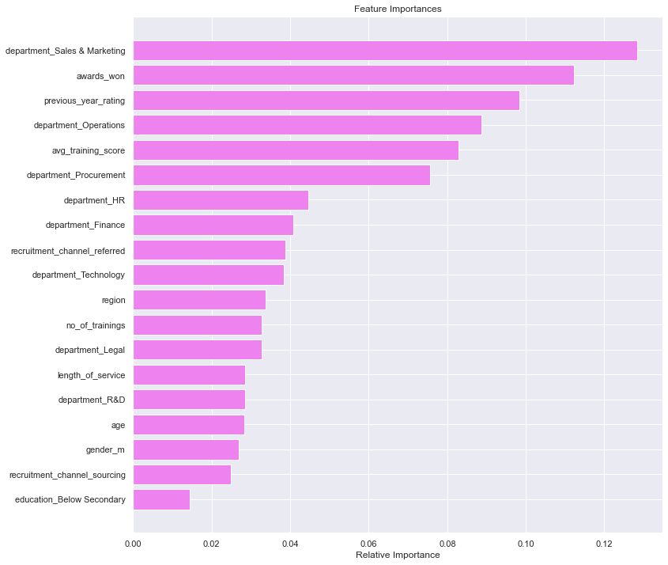

```python
feature_names = X_train.columns
importances = xgb_tuned2[1].feature_importances_
indices = np.argsort(importances)

plt.figure(figsize=(12, 12))
plt.title("Feature Importances")
plt.barh(range(len(indices)), importances[indices], color="violet", align="center")
plt.yticks(range(len(indices)), [feature_names[i] for i in indices])
plt.xlabel("Relative Importance")
plt.show()
```

Employees working in Sales & Marketing Department is most important value followed by awards won, previous years rating, employees in Operations Department, average training score, and employees working in Procurement department.

BUSINESS RECOMMENDATIONS

Predictive model built to:

```
1.  identify employees who will get a promotion.
2.  determine key factors that drive promotions.
3.  help company promote employees.
```

Factors that drive promotions: awards won, previous years rating, average training score, and employees working in Sales & Marketing, Operations, and Procurement. Awards won: Employees that have won awards are more likely to receive promotions. Previous years rating: Employees with higher ratings are more likely to receive promotions. Average training score: Employees with higher average training scores are more likely to receive promotions. Employees working in Sales & Marketing, Operations, and Procurement are more likely to receive promotions.